# ANOVA test for ortografia

Geiser C. Challco geiser@alumni.usp.br

- ANOVA: ortografia ~ time
  - Data Preparation
  - Summary Statistics
  - ANOVA Computation
  - PairWise Computation
- ANOVA: ortografia ~ time*gender + Error(id/time)
  - Data Preparation
    - Check assumptions: Identifying Outliers
    - Check assumptions: Normality Test
    - Summary Statistics
  - ANOVA Computation
  - ANOVA Computation after removing non.normal data
  - PairWise Computation
  - PairWise Computation after removing non.normal data
- ANOVA: ortografia ~ time*localizacao + Error(id/time)
  - Data Preparation
    - Check assumptions: Identifying Outliers
    - Check assumptions: Normality Test
    - Summary Statistics
  - ANOVA Computation
  - ANOVA Computation after removing non.normal data
  - PairWise Computation
  - PairWise Computation after removing non.normal data
- ANOVA: ortografia ~ time*regiao + Error(id/time)
  - Data Preparation
    - Check assumptions: Identifying Outliers
    - Check assumptions: Normality Test
    - Summary Statistics
  - ANOVA Computation
  - ANOVA Computation after removing non.normal data
  - PairWise Computation
  - PairWise Computation after removing non.normal data
- ANOVA: ortografia ~ time*porte + Error(id/time)
  - Data Preparation
    - Check assumptions: Identifying Outliers
    - Check assumptions: Normality Test
    - Summary Statistics
  - ANOVA Computation
  - ANOVA Computation after removing non.normal data
  - PairWise Computation

```r
dat <- read_excel("../data/data.xlsx", sheet = "alunos_ef14")

escolas <- read_excel("../data/data.xlsx", sheet = "escolas")
edat <- merge(dat, escolas, by = "cod_escola", all.x = T)
```

# ANOVA: ortografia ~ time

## Data Preparation

```r
data <- edat[,c("aluno_id","ciclo","ortografia")]
data <- data[data$ciclo %in% c("Primeiro Ciclo","Segundo Ciclo","Terceiro Ciclo","Quarto Ciclo"),]
data$ciclo <- factor(data$ciclo, c("Primeiro Ciclo","Segundo Ciclo","Terceiro Ciclo","Quarto Ciclo"))
data <- unique(data)

wdat <- spread(data, ciclo, ortografia)
wdat <- wdat[complete.cases(wdat),]
colnames(wdat) <- c("id","c1","c2","c3","c4")

ldat <- gather(wdat, key = time, value = ortografia, c1,c2,c3,c4) %>%
  convert_as_factor(id, time)
ldat <- rshinystatistics::remove_group_data(ldat, "ortografia", "time", n.limit = 30)
```

## Summary Statistics

```r
(sdat <- ldat %>% group_by(time) %>%
   get_summary_stats(ortografia, type = "mean_sd"))
```

```
## # A tibble: 4 × 5
##   time  variable       n  mean    sd
##   <fct> <fct>      <dbl> <dbl> <dbl>
## 1 c1    ortografia  1126  4.23 0.785
## 2 c2    ortografia  1126  3.97 0.793
## 3 c3    ortografia  1126  3.94 0.767
## 4 c4    ortografia  1126  3.92 0.776
```

| time | variable | n | mean | sd |
| --- | --- | --- | --- | --- |
| c1 | ortografia | 1126 | 4.226 | 0.785 |
| c2 | ortografia | 1126 | 3.970 | 0.793 |
| c3 | ortografia | 1126 | 3.944 | 0.767 |
| c4 | ortografia | 1126 | 3.921 | 0.776 |

## ANOVA Computation

```r
(res.aov <- anova_test(ldat, dv = ortografia, wid = id, within = time))
```

```
## ANOVA Table (type III tests)
##
## $ANOVA
##   Effect DFn  DFd      F        p p<.05   ges
## 1   time   3 3375 43.853 8.54e-28     * 0.024
##
## $`Mauchly's Test for Sphericity`
##   Effect     W     p p<.05
## 1   time 0.989 0.027     *
##
## $`Sphericity Corrections`
##   Effect   GGe        DF[GG]    p[GG] p[GG]<.05   HFe        DF[HF]    p[HF]
## 1   time 0.992 2.98, 3349.13 1.33e-27         * 0.995 2.99, 3358.99 1.12e-27
##   p[HF]<.05
## 1         *
```

| Effect | DFn | DFd | F | p | p<.05 | ges |
| --- | --- | --- | --- | --- | --- | --- |
| time | 3 | 3375 | 43.853 | 0 | * | 0.024 |

| Effect | W | p | p<.05 |
| --- | --- | --- | --- |
| time | 0.989 | 0.027 | * |

| Effect | GGe | DF $$GG$$ | p $$GG$$ | p $$GG$$ <.05 | HFe | DF $$HF$$ | p $$HF$$ | p $$HF$$ <.05 |
| --- | --- | --- | --- | --- | --- | --- | --- | --- |
| time | 0.992 | 2.98, 3349.13 | 0 | * | 0.995 | 2.99, 3358.99 | 0 | * |

## PairWise Computation

```r
(pwc <- ldat %>% emmeans_test(ortografia ~ time, detailed = T, p.adjust.method = "bonferroni"))
```

```
## # A tibble: 6 × 14
##   term  .y.    group1 group2 null.value estimate     se    df conf.low conf.high
## * <chr> <chr>  <chr>  <chr>       <dbl>    <dbl>  <dbl> <dbl>    <dbl>     <dbl>
## 1 time  ortog… c1     c2              0   0.256  0.0329  4500   0.191     0.320
## 2 time  ortog… c1     c3              0   0.282  0.0329  4500   0.217     0.346
## 3 time  ortog… c1     c4              0   0.305  0.0329  4500   0.241     0.370
## 4 time  ortog… c2     c3              0   0.0261 0.0329  4500  -0.0384    0.0905
## 5 time  ortog… c2     c4              0   0.0496 0.0329  4500  -0.0149    0.114
## 6 time  ortog… c3     c4              0   0.0235 0.0329  4500  -0.0410    0.0880
## # ℹ 4 more variables: statistic <dbl>, p <dbl>, p.adj <dbl>, p.adj.signif <chr>
```

| term | .y. | group1 | group2 | null.value | estimate | se | df | conf.low | conf.high | statistic | p | p.adj | p.adj.signif |
| --- | --- | --- | --- | --- | --- | --- | --- | --- | --- | --- | --- | --- | --- |
| time | ortografia | c1 | c2 | 0 | 0.256 | 0.033 | 4500 | 0.191 | 0.320 | 7.772 | 0.000 | 0.00 | **** |
| time | ortografia | c1 | c3 | 0 | 0.282 | 0.033 | 4500 | 0.217 | 0.346 | 8.564 | 0.000 | 0.00 | **** |
| time | ortografia | c1 | c4 | 0 | 0.305 | 0.033 | 4500 | 0.241 | 0.370 | 9.279 | 0.000 | 0.00 | **** |
| time | ortografia | c2 | c3 | 0 | 0.026 | 0.033 | 4500 | -0.038 | 0.091 | 0.792 | 0.428 | 1.00 | ns |
| time | ortografia | c2 | c4 | 0 | 0.050 | 0.033 | 4500 | -0.015 | 0.114 | 1.508 | 0.132 | 0.79 | ns |
| time | ortografia | c3 | c4 | 0 | 0.024 | 0.033 | 4500 | -0.041 | 0.088 | 0.716 | 0.474 | 1.00 | ns |

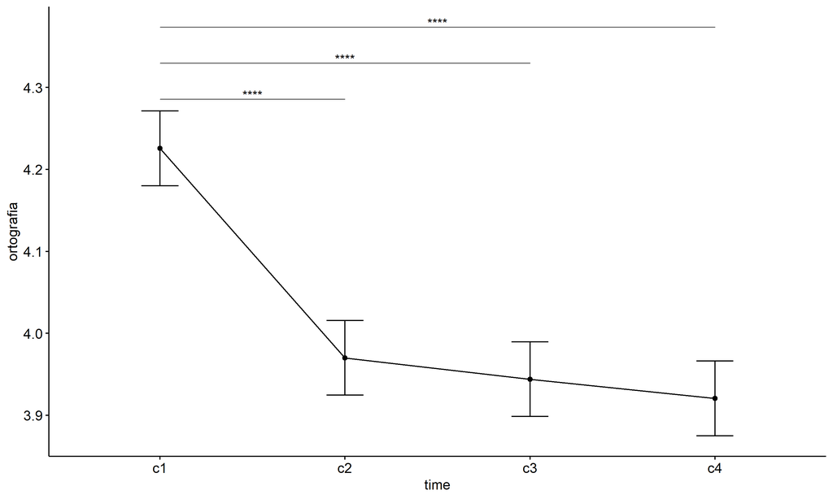

```r
pwc <- add_xy_position(pwc, x = "time", fun = "mean_se")
ggline(get_emmeans(pwc), x = "time", y = "emmean", ylab = "ortografia") +
  geom_errorbar(aes(ymin = conf.low, ymax = conf.high), width = 0.2) +
  stat_pvalue_manual(pwc, hide.ns = T, tip.length = F)
```

# ANOVA: ortografia ~ time*gender + Error(id/time)

## Data Preparation

```r
data <- edat[,c("aluno_id","gender","ciclo","ortografia")]
data <- data[data$ciclo %in% c("Primeiro Ciclo","Segundo Ciclo","Terceiro Ciclo","Quarto Ciclo"),]
data$ciclo <- factor(data$ciclo, c("Primeiro Ciclo","Segundo Ciclo","Terceiro Ciclo","Quarto Ciclo"))
data <- unique(data)

wdat <- spread(data, ciclo, ortografia)
wdat <- wdat[complete.cases(wdat),]
colnames(wdat) <- c("id","gender","c1","c2","c3","c4")

ldat <- gather(wdat, key = time, value = ortografia, c1,c2,c3,c4) %>%
  convert_as_factor(id, time)
ldat <- remove_group_data(ldat, "ortografia", c("time", "gender"), n.limit = 30)
ldat$gender <- factor(ldat$gender, sort(unique(ldat$gender)))
```

### Check assumptions: Identifying Outliers

```r
outliers <- identify_outliers(group_by(ldat, time, gender), ortografia)
(outliers <- outliers[outliers$is.extreme == T,])
```

```
## [1] gender     time       id         ortografia is.outlier is.extreme
## <0 rows> (or 0-length row.names)
```

| gender | time | id | ortografia | is.outlier | is.extreme |
| --- | --- | --- | --- | --- | --- |

### Check assumptions: Normality Test

```r
(normality.df <- normality.test.per.groups(ldat, "ortografia", c("time", "gender")))
```

```
##          var   variable time gender   n     skewness  kurtosis symmetry
## 1 ortografia ortografia   c1 Female 552 -0.376083415 -1.320924      YES
## 2 ortografia ortografia   c1   Male 513 -0.520483005 -1.248268       NO
## 3 ortografia ortografia   c2 Female 552  0.077888733 -1.478998      YES
## 4 ortografia ortografia   c2   Male 513  0.002822173 -1.460892      YES
## 5 ortografia ortografia   c3 Female 552  0.103115900 -1.370211      YES
## 6 ortografia ortografia   c3   Male 513  0.019183698 -1.355139      YES
## 7 ortografia ortografia   c4 Female 552  0.019732006 -1.399905      YES
## 8 ortografia ortografia   c4   Male 513  0.209771757 -1.425977      YES
##    statistic     method p p.signif normality
## 1  1100.9881 D'Agostino 0     ****         -
## 2   471.1104 D'Agostino 0     ****         -
## 3  5321.1559 D'Agostino 0     ****         -
## 4  5860.1509 D'Agostino 0     ****         -
## 5  3023.2555 D'Agostino 0     ****         -
## 6  1691.0401 D'Agostino 0     ****         -
## 7 35944.3849 D'Agostino 0     ****         -
## 8  9306.7505 D'Agostino 0     ****         -
```

| var | variable | time | gender | n | skewness | kurtosis | symmetry | statistic | method | p | p.signif | normality |
| --- | --- | --- | --- | --- | --- | --- | --- | --- | --- | --- | --- | --- |
| ortografia | ortografia | c1 | Female | 552 | -0.376 | -1.321 | YES | 1100.988 | D’Agostino | 0 | **** | - |
| ortografia | ortografia | c1 | Male | 513 | -0.520 | -1.248 | NO | 471.110 | D’Agostino | 0 | **** | - |
| ortografia | ortografia | c2 | Female | 552 | 0.078 | -1.479 | YES | 5321.156 | D’Agostino | 0 | **** | - |
| ortografia | ortografia | c2 | Male | 513 | 0.003 | -1.461 | YES | 5860.151 | D’Agostino | 0 | **** | - |
| ortografia | ortografia | c3 | Female | 552 | 0.103 | -1.370 | YES | 3023.255 | D’Agostino | 0 | **** | - |
| ortografia | ortografia | c3 | Male | 513 | 0.019 | -1.355 | YES | 1691.040 | D’Agostino | 0 | **** | - |
| ortografia | ortografia | c4 | Female | 552 | 0.020 | -1.400 | YES | 35944.385 | D’Agostino | 0 | **** | - |
| ortografia | ortografia | c4 | Male | 513 | 0.210 | -1.426 | YES | 9306.751 | D’Agostino | 0 | **** | - |

```r
(non.ids <- unique(do.call(
  c, lapply(which(normality.df$normality == 'NO'), FUN = function(i) {
  idx = which(ldat$time == normality.df$time[i] &
                ldat$gender == normality.df$gender[i])
  getNonNormal(ldat$"ortografia"[idx], ldat$id[idx])
}))))
```

```r
if (length(non.ids) > 0)
  ldat2 <- ldat[!ldat$id %in% non.ids,]
```

### Summary Statistics

```r
(sdat <- ldat %>% group_by(time, gender) %>%
   get_summary_stats(ortografia, type = "mean_sd"))
```

```
## # A tibble: 8 × 6
##   gender time  variable       n  mean    sd
##   <fct>  <fct> <fct>      <dbl> <dbl> <dbl>
## 1 Female c1    ortografia   552  4.19 0.782
## 2 Male   c1    ortografia   513  4.26 0.787
## 3 Female c2    ortografia   552  3.94 0.8
## 4 Male   c2    ortografia   513  3.99 0.792
## 5 Female c3    ortografia   552  3.92 0.768
## 6 Male   c3    ortografia   513  3.98 0.761
## 7 Female c4    ortografia   552  3.98 0.774
## 8 Male   c4    ortografia   513  3.86 0.782
```

| gender | time | variable | n | mean | sd |
| --- | --- | --- | --- | --- | --- |
| Female | c1 | ortografia | 552 | 4.190 | 0.782 |
| Male | c1 | ortografia | 513 | 4.259 | 0.787 |
| Female | c2 | ortografia | 552 | 3.944 | 0.800 |
| Male | c2 | ortografia | 513 | 3.988 | 0.792 |
| Female | c3 | ortografia | 552 | 3.919 | 0.768 |
| Male | c3 | ortografia | 513 | 3.980 | 0.761 |
| Female | c4 | ortografia | 552 | 3.977 | 0.774 |
| Male | c4 | ortografia | 513 | 3.861 | 0.782 |

```r
if (length(non.ids) > 0)
  (sdat <- ldat2 %>% group_by(time, gender) %>%
      get_summary_stats(ortografia, type = "mean_sd"))
```

[output not shown]

## ANOVA Computation

```r
(res.aov <- anova_test(ldat, dv = ortografia, wid = id, between = gender, within = time))
```

```
## ANOVA Table (type III tests)
##
## $ANOVA
##        Effect DFn  DFd      F        p p<.05      ges
## 1      gender   1 1063  0.238 6.26e-01       8.13e-05
## 2        time   3 3189 41.000 5.44e-26     * 2.40e-02
## 3 gender:time   3 3189  3.962 8.00e-03     * 2.00e-03
##
## $`Mauchly's Test for Sphericity`
##        Effect    W     p p<.05
## 1        time 0.99 0.049     *
## 2 gender:time 0.99 0.049     *
##
## $`Sphericity Corrections`
##        Effect   GGe        DF[GG]    p[GG] p[GG]<.05   HFe        DF[HF]
## 1        time 0.993 2.98, 3166.29 7.98e-26         * 0.996 2.99, 3176.16
## 2 gender:time 0.993 2.98, 3166.29 8.00e-03         * 0.996 2.99, 3176.16
##      p[HF] p[HF]<.05
## 1 6.75e-26         *
## 2 8.00e-03         *
```

| Effect | DFn | DFd | F | p | p<.05 | ges |
| --- | --- | --- | --- | --- | --- | --- |
| gender | 1 | 1063 | 0.238 | 0.626 |  | 0.000 |
| time | 3 | 3189 | 41.000 | 0.000 | * | 0.024 |
| gender:time | 3 | 3189 | 3.962 | 0.008 | * | 0.002 |

| Effect | W | p | p<.05 |
| --- | --- | --- | --- |
| time | 0.99 | 0.049 | * |
| gender:time | 0.99 | 0.049 | * |

| Effect | GGe | DF $$GG$$ | p $$GG$$ | p $$GG$$ <.05 | HFe | DF $$HF$$ | p $$HF$$ | p $$HF$$ <.05 |
| --- | --- | --- | --- | --- | --- | --- | --- | --- |
| time | 0.993 | 2.98, 3166.29 | 0.000 | * | 0.996 | 2.99, 3176.16 | 0.000 | * |
| gender:time | 0.993 | 2.98, 3166.29 | 0.008 | * | 0.996 | 2.99, 3176.16 | 0.008 | * |

## ANOVA Computation after removing non.normal data

```r
if (length(non.ids) > 0)
  (res.aov2 <- anova_test(ldat2, dv = ortografia, wid = id, between = gender , within = time))
```

## PairWise Computation

```r
(pwc <- ldat %>% group_by(time) %>%
   emmeans_test(ortografia ~ gender, detailed = T, p.adjust.method = "bonferroni"))
```

```
## # A tibble: 4 × 15
##   time  term   .y.       group1 group2 null.value estimate     se    df conf.low
## * <fct> <chr>  <chr>     <chr>  <chr>       <dbl>    <dbl>  <dbl> <dbl>    <dbl>
## 1 c1    gender ortograf… Female Male            0  -0.0690 0.0479  4252  -0.163
## 2 c2    gender ortograf… Female Male            0  -0.0439 0.0479  4252  -0.138
## 3 c3    gender ortograf… Female Male            0  -0.0601 0.0479  4252  -0.154
## 4 c4    gender ortograf… Female Male            0   0.117  0.0479  4252   0.0228
## # ℹ 5 more variables: conf.high <dbl>, statistic <dbl>, p <dbl>, p.adj <dbl>,
## #   p.adj.signif <chr>
```

| time | term | .y. | group1 | group2 | null.value | estimate | se | df | conf.low | conf.high | statistic | p | p.adj | p.adj.signif |
| --- | --- | --- | --- | --- | --- | --- | --- | --- | --- | --- | --- | --- | --- | --- |
| c1 | gender | ortografia | Female | Male | 0 | -0.069 | 0.048 | 4252 | -0.163 | 0.025 | -1.442 | 0.149 | 0.149 | ns |
| c2 | gender | ortografia | Female | Male | 0 | -0.044 | 0.048 | 4252 | -0.138 | 0.050 | -0.916 | 0.360 | 0.360 | ns |
| c3 | gender | ortografia | Female | Male | 0 | -0.060 | 0.048 | 4252 | -0.154 | 0.034 | -1.256 | 0.209 | 0.209 | ns |
| c4 | gender | ortografia | Female | Male | 0 | 0.117 | 0.048 | 4252 | 0.023 | 0.211 | 2.438 | 0.015 | 0.015 | * |

```r
(emms <- get_emmeans(pwc))
```

```
## # A tibble: 8 × 8
##   time  gender emmean     se    df conf.low conf.high method
##   <fct> <fct>   <dbl>  <dbl> <dbl>    <dbl>     <dbl> <chr>
## 1 c1    Female   4.19 0.0332  4252     4.13      4.26 Emmeans test
## 2 c1    Male     4.26 0.0345  4252     4.19      4.33 Emmeans test
## 3 c2    Female   3.94 0.0332  4252     3.88      4.01 Emmeans test
## 4 c2    Male     3.99 0.0345  4252     3.92      4.06 Emmeans test
## 5 c3    Female   3.92 0.0332  4252     3.85      3.98 Emmeans test
## 6 c3    Male     3.98 0.0345  4252     3.91      4.05 Emmeans test
## 7 c4    Female   3.98 0.0332  4252     3.91      4.04 Emmeans test
## 8 c4    Male     3.86 0.0345  4252     3.79      3.93 Emmeans test
```

| time | gender | emmean | se | df | conf.low | conf.high | method |
| --- | --- | --- | --- | --- | --- | --- | --- |
| c1 | Female | 4.190 | 0.033 | 4252 | 4.125 | 4.255 | Emmeans test |
| c1 | Male | 4.259 | 0.034 | 4252 | 4.192 | 4.327 | Emmeans test |
| c2 | Female | 3.944 | 0.033 | 4252 | 3.879 | 4.010 | Emmeans test |
| c2 | Male | 3.988 | 0.034 | 4252 | 3.921 | 4.056 | Emmeans test |
| c3 | Female | 3.919 | 0.033 | 4252 | 3.854 | 3.985 | Emmeans test |
| c3 | Male | 3.980 | 0.034 | 4252 | 3.912 | 4.047 | Emmeans test |
| c4 | Female | 3.977 | 0.033 | 4252 | 3.912 | 4.043 | Emmeans test |
| c4 | Male | 3.861 | 0.034 | 4252 | 3.793 | 3.928 | Emmeans test |

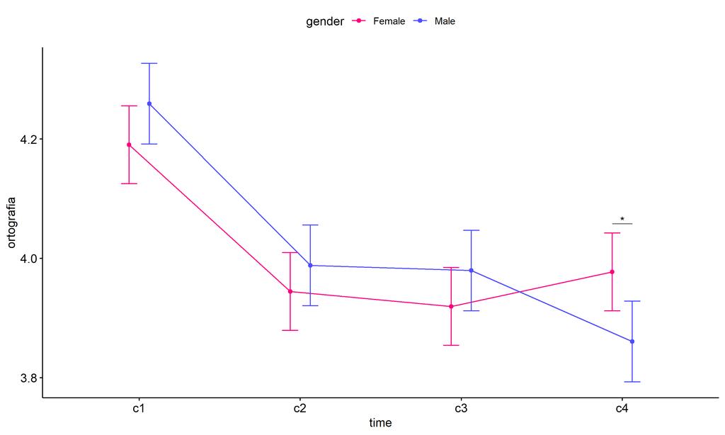

```r
pwc <- add_xy_position(pwc, x = "time", fun = "mean_se", dodge = 0.25)
pd <- position_dodge(width = 0.25)
ggline(emms, x = "time", y = "emmean", color = "gender",
       palette = c("#FF007F","#4D4DFF"),
       position = pd, ylab = "ortografia") +
  geom_errorbar(aes(ymin = conf.low, ymax = conf.high, color = gender),
                position = pd, width = 0.2) +
  stat_pvalue_manual(pwc, hide.ns = T, tip.length = F, linetype = 1)
```

```r
(pwc <- ldat %>% group_by(gender) %>%
    emmeans_test(ortografia ~ time, detailed = T, p.adjust.method = "bonferroni"))
```

```
## # A tibble: 12 × 15
##    gender term  .y.      group1 group2 null.value estimate     se    df conf.low
##  * <fct>  <chr> <chr>    <chr>  <chr>       <dbl>    <dbl>  <dbl> <dbl>    <dbl>
##  1 Female time  ortogra… c1     c2              0  0.246   0.0470  4252   0.154
##  2 Female time  ortogra… c1     c3              0  0.271   0.0470  4252   0.179
##  3 Female time  ortogra… c1     c4              0  0.213   0.0470  4252   0.121
##  4 Female time  ortogra… c2     c3              0  0.0251  0.0470  4252  -0.0671
##  5 Female time  ortogra… c2     c4              0 -0.0329  0.0470  4252  -0.125
##  6 Female time  ortogra… c3     c4              0 -0.0580  0.0470  4252  -0.150
##  7 Male   time  ortogra… c1     c2              0  0.271   0.0488  4252   0.175
##  8 Male   time  ortogra… c1     c3              0  0.280   0.0488  4252   0.184
##  9 Male   time  ortogra… c1     c4              0  0.399   0.0488  4252   0.303
## 10 Male   time  ortogra… c2     c3              0  0.00877 0.0488  4252  -0.0868
## 11 Male   time  ortogra… c2     c4              0  0.128   0.0488  4252   0.0321
## 12 Male   time  ortogra… c3     c4              0  0.119   0.0488  4252   0.0233
## # ℹ 5 more variables: conf.high <dbl>, statistic <dbl>, p <dbl>, p.adj <dbl>,
## #   p.adj.signif <chr>
```

| gender | term | .y. | group1 | group2 | null.value | estimate | se | df | conf.low | conf.high | statistic | p | p.adj | p.adj.signif |
| --- | --- | --- | --- | --- | --- | --- | --- | --- | --- | --- | --- | --- | --- | --- |
| Female | time | ortografia | c1 | c2 | 0 | 0.246 | 0.047 | 4252 | 0.154 | 0.338 | 5.229 | 0.000 | 0.000 | **** |
| Female | time | ortografia | c1 | c3 | 0 | 0.271 | 0.047 | 4252 | 0.179 | 0.363 | 5.762 | 0.000 | 0.000 | **** |
| Female | time | ortografia | c1 | c4 | 0 | 0.213 | 0.047 | 4252 | 0.121 | 0.305 | 4.529 | 0.000 | 0.000 | **** |
| Female | time | ortografia | c2 | c3 | 0 | 0.025 | 0.047 | 4252 | -0.067 | 0.117 | 0.533 | 0.594 | 1.000 | ns |
| Female | time | ortografia | c2 | c4 | 0 | -0.033 | 0.047 | 4252 | -0.125 | 0.059 | -0.700 | 0.484 | 1.000 | ns |
| Female | time | ortografia | c3 | c4 | 0 | -0.058 | 0.047 | 4252 | -0.150 | 0.034 | -1.233 | 0.218 | 1.000 | ns |
| Male | time | ortografia | c1 | c2 | 0 | 0.271 | 0.049 | 4252 | 0.175 | 0.367 | 5.557 | 0.000 | 0.000 | **** |
| Male | time | ortografia | c1 | c3 | 0 | 0.280 | 0.049 | 4252 | 0.184 | 0.375 | 5.737 | 0.000 | 0.000 | **** |
| Male | time | ortografia | c1 | c4 | 0 | 0.399 | 0.049 | 4252 | 0.303 | 0.494 | 8.176 | 0.000 | 0.000 | **** |
| Male | time | ortografia | c2 | c3 | 0 | 0.009 | 0.049 | 4252 | -0.087 | 0.104 | 0.180 | 0.857 | 1.000 | ns |
| Male | time | ortografia | c2 | c4 | 0 | 0.128 | 0.049 | 4252 | 0.032 | 0.223 | 2.619 | 0.009 | 0.053 | ns |
| Male | time | ortografia | c3 | c4 | 0 | 0.119 | 0.049 | 4252 | 0.023 | 0.214 | 2.439 | 0.015 | 0.089 | ns |

```r
(emms <- get_emmeans(pwc))
```

```
## # A tibble: 8 × 8
##   gender time  emmean     se    df conf.low conf.high method
##   <fct>  <fct>  <dbl>  <dbl> <dbl>    <dbl>     <dbl> <chr>
## 1 Female c1      4.19 0.0332  4252     4.13      4.26 Emmeans test
## 2 Female c2      3.94 0.0332  4252     3.88      4.01 Emmeans test
## 3 Female c3      3.92 0.0332  4252     3.85      3.98 Emmeans test
## 4 Female c4      3.98 0.0332  4252     3.91      4.04 Emmeans test
## 5 Male   c1      4.26 0.0345  4252     4.19      4.33 Emmeans test
## 6 Male   c2      3.99 0.0345  4252     3.92      4.06 Emmeans test
## 7 Male   c3      3.98 0.0345  4252     3.91      4.05 Emmeans test
## 8 Male   c4      3.86 0.0345  4252     3.79      3.93 Emmeans test
```

| gender | time | emmean | se | df | conf.low | conf.high | method |
| --- | --- | --- | --- | --- | --- | --- | --- |
| Female | c1 | 4.190 | 0.033 | 4252 | 4.125 | 4.255 | Emmeans test |
| Female | c2 | 3.944 | 0.033 | 4252 | 3.879 | 4.010 | Emmeans test |
| Female | c3 | 3.919 | 0.033 | 4252 | 3.854 | 3.985 | Emmeans test |
| Female | c4 | 3.977 | 0.033 | 4252 | 3.912 | 4.043 | Emmeans test |
| Male | c1 | 4.259 | 0.034 | 4252 | 4.192 | 4.327 | Emmeans test |
| Male | c2 | 3.988 | 0.034 | 4252 | 3.921 | 4.056 | Emmeans test |
| Male | c3 | 3.980 | 0.034 | 4252 | 3.912 | 4.047 | Emmeans test |
| Male | c4 | 3.861 | 0.034 | 4252 | 3.793 | 3.928 | Emmeans test |

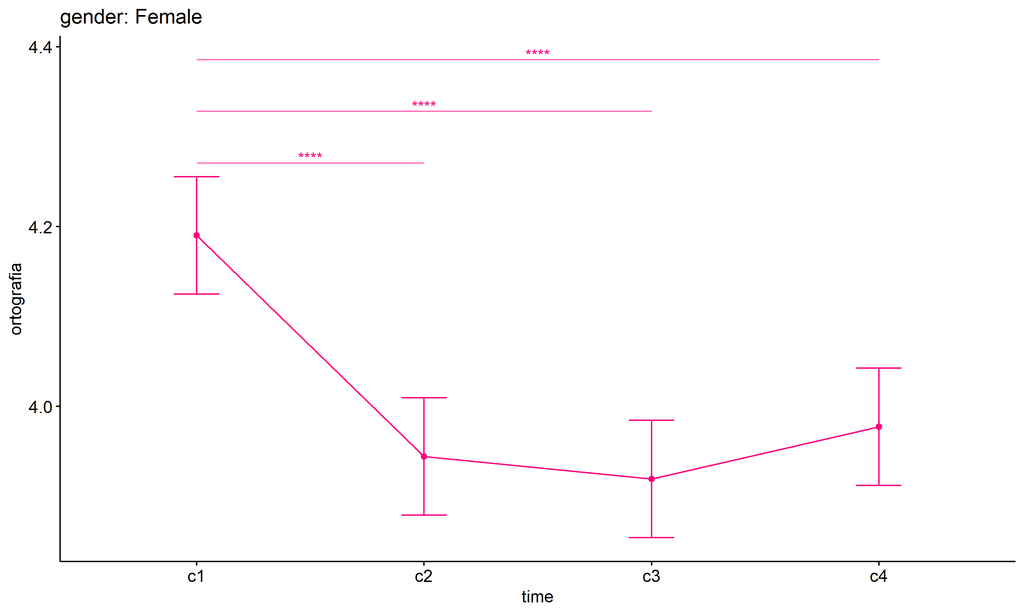

```r
emms.gg <- emms[which(emms$gender == "Female"),]
if (nrow(emms.gg) > 0)
  ggline(emms.gg, x = "time", y = "emmean", color = "#FF007F", ylab = "ortografia") +
    geom_errorbar(aes(ymin = conf.low, ymax = conf.high),
                  width = 0.2, color = "#FF007F") +
    stat_pvalue_manual(
      add_xy_position(pwc[which(pwc$gender == "Female"),],
                      x = "time", fun = "mean_se"),
      hide.ns = T, color = "#FF007F", tip.length = F) +
    labs(title = "gender: Female")+
    theme(legend.text = element_blank())
```

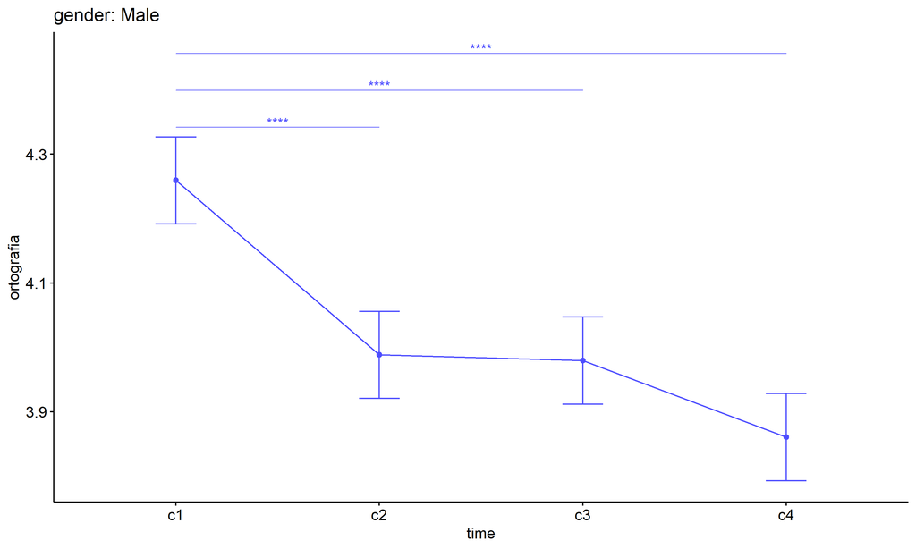

```r
emms.gg <- emms[which(emms$gender == "Male"),]
if (nrow(emms.gg) > 0)
  ggline(emms.gg, x = "time", y = "emmean", color = "#4D4DFF", ylab = "ortografia") +
    geom_errorbar(aes(ymin = conf.low, ymax = conf.high),
                  width = 0.2, color = "#4D4DFF") +
    stat_pvalue_manual(
      add_xy_position(pwc[which(pwc$gender == "Male"),],
                      x = "time", fun = "mean_se"),
      hide.ns = T, color = "#4D4DFF", tip.length = F) +
    labs(title = "gender: Male")+
    theme(legend.text = element_blank())
```

## PairWise Computation after removing non.normal data

```r
if (length(non.ids) > 0)
  (pwc2 <- ldat2 %>% group_by(time) %>%
     emmeans_test(ortografia ~ gender, detailed = T, p.adjust.method = "bonferroni"))
```

```r
if (length(non.ids) > 0)
  (emms2 <- get_emmeans(pwc2))
```

```r
if (length(non.ids) > 0) {
  pwc2 <- add_xy_position(pwc2, x = "time", fun = "mean_se", dodge = 0.25)
  pd2 <- position_dodge(width = 0.25)

  ggline(emms2, x = "time", y = "emmean", color = "gender",
         palette = c("#FF007F","#4D4DFF"),
         position = pd, ylab = "ortografia") +
    geom_errorbar(aes(ymin = conf.low, ymax = conf.high, color = gender),
                position = pd, width = 0.2) +
    stat_pvalue_manual(pwc2, hide.ns = T, tip.length = F, linetype = 1)
}
```

```r
if (length(non.ids) > 0)
  (pwc2 <- ldat2 %>% group_by(gender) %>%
     emmeans_test(ortografia ~ time, detailed = T, p.adjust.method = "bonferroni"))
```

```r
if (length(non.ids) > 0)
  (emms2 <- get_emmeans(pwc2))
```

```r
if (length(non.ids) > 0) {
  emms.gg <- emms2[which(emms2$gender == "Female"),]
  if (nrow(emms.gg) > 0)
    ggline(emms.gg, x = "time", y = "emmean", color = "#FF007F", ylab = "ortografia") +
    geom_errorbar(aes(ymin = conf.low, ymax = conf.high),
                  width = 0.2, color = "#FF007F") +
    stat_pvalue_manual(
      add_xy_position(pwc[which(pwc$gender == "Female"),],
                      x = "time", fun = "mean_se"),
      hide.ns = T, color = "#FF007F", tip.length = F) +
    labs(title = "gender: Female") +
    theme(legend.text = element_blank())
}
```

```r
if (length(non.ids) > 0) {
  emms.gg <- emms2[which(emms2$gender == "Male"),]
  if (nrow(emms.gg) > 0)
    ggline(emms.gg, x = "time", y = "emmean", color = "#4D4DFF", ylab = "ortografia") +
    geom_errorbar(aes(ymin = conf.low, ymax = conf.high),
                  width = 0.2, color = "#4D4DFF") +
    stat_pvalue_manual(
      add_xy_position(pwc[which(pwc$gender == "Male"),],
                      x = "time", fun = "mean_se"),
      hide.ns = T, color = "#4D4DFF", tip.length = F) +
    labs(title = "gender: Male") +
    theme(legend.text = element_blank())
}
```

# ANOVA: ortografia ~ time*localizacao + Error(id/time)

## Data Preparation

```r
data <- edat[,c("aluno_id","localizacao","ciclo","ortografia")]
data <- data[data$ciclo %in% c("Primeiro Ciclo","Segundo Ciclo","Terceiro Ciclo","Quarto Ciclo"),]
data$ciclo <- factor(data$ciclo, c("Primeiro Ciclo","Segundo Ciclo","Terceiro Ciclo","Quarto Ciclo"))
data <- unique(data)

wdat <- spread(data, ciclo, ortografia)
wdat <- wdat[complete.cases(wdat),]
colnames(wdat) <- c("id","localizacao","c1","c2","c3","c4")

ldat <- gather(wdat, key = time, value = ortografia, c1,c2,c3,c4) %>%
  convert_as_factor(id, time)
ldat <- remove_group_data(ldat, "ortografia", c("time", "localizacao"), n.limit = 30)
ldat$localizacao <- factor(ldat$localizacao, sort(unique(ldat$localizacao)))
```

### Check assumptions: Identifying Outliers

```r
outliers <- identify_outliers(group_by(ldat, time, localizacao), ortografia)
(outliers <- outliers[outliers$is.extreme == T,])
```

```
## [1] localizacao time        id          ortografia  is.outlier  is.extreme
## <0 rows> (or 0-length row.names)
```

| localizacao | time | id | ortografia | is.outlier | is.extreme |
| --- | --- | --- | --- | --- | --- |

### Check assumptions: Normality Test

```r
(normality.df <- normality.test.per.groups(ldat, "ortografia", c("time", "localizacao")))
```

```
##          var   variable time localizacao   n    skewness  kurtosis symmetry
## 1 ortografia ortografia   c1       Rural 181 -0.56126204 -1.126250       NO
## 2 ortografia ortografia   c1      Urbana 945 -0.42568385 -1.317504      YES
## 3 ortografia ortografia   c2       Rural 181 -0.05024091 -1.545970      YES
## 4 ortografia ortografia   c2      Urbana 945  0.04657452 -1.445309      YES
## 5 ortografia ortografia   c3       Rural 181  0.23167022 -1.322238      YES
## 6 ortografia ortografia   c3      Urbana 945  0.04076148 -1.377860      YES
## 7 ortografia ortografia   c4       Rural 181  0.23336592 -1.492570      YES
## 8 ortografia ortografia   c4      Urbana 945  0.09034653 -1.388926      YES
##     statistic     method            p p.signif normality
## 1    58.40701 D'Agostino 2.075007e-13     ****        QQ
## 2  2558.52523 D'Agostino 0.000000e+00     ****         -
## 3  3756.36706 D'Agostino 0.000000e+00     ****        QQ
## 4  9009.30547 D'Agostino 0.000000e+00     ****         -
## 5   153.13327 D'Agostino 0.000000e+00     ****        QQ
## 6 32632.08646 D'Agostino 0.000000e+00     ****         -
## 7  1435.51384 D'Agostino 0.000000e+00     ****        QQ
## 8 18811.57421 D'Agostino 0.000000e+00     ****         -
```

| var | variable | time | localizacao | n | skewness | kurtosis | symmetry | statistic | method | p | p.signif | normality |
| --- | --- | --- | --- | --- | --- | --- | --- | --- | --- | --- | --- | --- |
| ortografia | ortografia | c1 | Rural | 181 | -0.561 | -1.126 | NO | 58.407 | D’Agostino | 0 | **** | QQ |
| ortografia | ortografia | c1 | Urbana | 945 | -0.426 | -1.318 | YES | 2558.525 | D’Agostino | 0 | **** | - |
| ortografia | ortografia | c2 | Rural | 181 | -0.050 | -1.546 | YES | 3756.367 | D’Agostino | 0 | **** | QQ |
| ortografia | ortografia | c2 | Urbana | 945 | 0.047 | -1.445 | YES | 9009.305 | D’Agostino | 0 | **** | - |
| ortografia | ortografia | c3 | Rural | 181 | 0.232 | -1.322 | YES | 153.133 | D’Agostino | 0 | **** | QQ |
| ortografia | ortografia | c3 | Urbana | 945 | 0.041 | -1.378 | YES | 32632.086 | D’Agostino | 0 | **** | - |
| ortografia | ortografia | c4 | Rural | 181 | 0.233 | -1.493 | YES | 1435.514 | D’Agostino | 0 | **** | QQ |
| ortografia | ortografia | c4 | Urbana | 945 | 0.090 | -1.389 | YES | 18811.574 | D’Agostino | 0 | **** | - |

```r
(non.ids <- unique(do.call(
  c, lapply(which(normality.df$normality == 'NO'), FUN = function(i) {
  idx = which(ldat$time == normality.df$time[i] &
                ldat$localizacao == normality.df$localizacao[i])
  getNonNormal(ldat$"ortografia"[idx], ldat$id[idx])
}))))
```

```r
if (length(non.ids) > 0)
  ldat2 <- ldat[!ldat$id %in% non.ids,]
```

### Summary Statistics

```r
(sdat <- ldat %>% group_by(time, localizacao) %>%
   get_summary_stats(ortografia, type = "mean_sd"))
```

```
## # A tibble: 8 × 6
##   localizacao time  variable       n  mean    sd
##   <fct>       <fct> <fct>      <dbl> <dbl> <dbl>
## 1 Rural       c1    ortografia   181  4.27 0.765
## 2 Urbana      c1    ortografia   945  4.22 0.788
## 3 Rural       c2    ortografia   181  4.01 0.82
## 4 Urbana      c2    ortografia   945  3.96 0.788
## 5 Rural       c3    ortografia   181  3.88 0.757
## 6 Urbana      c3    ortografia   945  3.96 0.769
## 7 Rural       c4    ortografia   181  3.87 0.804
## 8 Urbana      c4    ortografia   945  3.93 0.771
```

| localizacao | time | variable | n | mean | sd |
| --- | --- | --- | --- | --- | --- |
| Rural | c1 | ortografia | 181 | 4.273 | 0.765 |
| Urbana | c1 | ortografia | 945 | 4.217 | 0.788 |
| Rural | c2 | ortografia | 181 | 4.011 | 0.820 |
| Urbana | c2 | ortografia | 945 | 3.962 | 0.788 |
| Rural | c3 | ortografia | 181 | 3.881 | 0.757 |
| Urbana | c3 | ortografia | 945 | 3.956 | 0.769 |
| Rural | c4 | ortografia | 181 | 3.867 | 0.804 |
| Urbana | c4 | ortografia | 945 | 3.931 | 0.771 |

```r
if (length(non.ids) > 0)
  (sdat <- ldat2 %>% group_by(time, localizacao) %>%
      get_summary_stats(ortografia, type = "mean_sd"))
```

[output not shown]

## ANOVA Computation

```r
(res.aov <- anova_test(ldat, dv = ortografia, wid = id, between = localizacao, within = time))
```

```
## ANOVA Table (type III tests)
##
## $ANOVA
##             Effect DFn  DFd      F        p p<.05      ges
## 1      localizacao   1 1124  0.045 8.32e-01       1.46e-05
## 2             time   3 3372 29.961 4.13e-19     * 1.70e-02
## 3 localizacao:time   3 3372  1.467 2.22e-01       8.29e-04
##
## $`Mauchly's Test for Sphericity`
##             Effect     W     p p<.05
## 1             time 0.989 0.029     *
## 2 localizacao:time 0.989 0.029     *
##
## $`Sphericity Corrections`
##             Effect   GGe        DF[GG]    p[GG] p[GG]<.05   HFe        DF[HF]
## 1             time 0.992 2.98, 3346.42 5.51e-19         * 0.995 2.99, 3356.28
## 2 localizacao:time 0.992 2.98, 3346.42 2.22e-01           0.995 2.99, 3356.28
##      p[HF] p[HF]<.05
## 1 4.93e-19         *
## 2 2.22e-01
```

| Effect | DFn | DFd | F | p | p<.05 | ges |
| --- | --- | --- | --- | --- | --- | --- |
| localizacao | 1 | 1124 | 0.045 | 0.832 |  | 0.000 |
| time | 3 | 3372 | 29.961 | 0.000 | * | 0.017 |
| localizacao:time | 3 | 3372 | 1.467 | 0.222 |  | 0.001 |

| Effect | W | p | p<.05 |
| --- | --- | --- | --- |
| time | 0.989 | 0.029 | * |
| localizacao:time | 0.989 | 0.029 | * |

| Effect | GGe | DF $$GG$$ | p $$GG$$ | p $$GG$$ <.05 | HFe | DF $$HF$$ | p $$HF$$ | p $$HF$$ <.05 |
| --- | --- | --- | --- | --- | --- | --- | --- | --- |
| time | 0.992 | 2.98, 3346.42 | 0.000 | * | 0.995 | 2.99, 3356.28 | 0.000 | * |
| localizacao:time | 0.992 | 2.98, 3346.42 | 0.222 |  | 0.995 | 2.99, 3356.28 | 0.222 |  |

## ANOVA Computation after removing non.normal data

```r
if (length(non.ids) > 0)
  (res.aov2 <- anova_test(ldat2, dv = ortografia, wid = id, between = localizacao , within = time))
```

## PairWise Computation

```r
(pwc <- ldat %>% group_by(time) %>%
   emmeans_test(ortografia ~ localizacao, detailed = T, p.adjust.method = "bonferroni"))
```

```
## # A tibble: 4 × 15
##   time  term       .y.   group1 group2 null.value estimate     se    df conf.low
## * <fct> <chr>      <chr> <chr>  <chr>       <dbl>    <dbl>  <dbl> <dbl>    <dbl>
## 1 c1    localizac… orto… Rural  Urbana          0   0.0569 0.0633  4496  -0.0672
## 2 c2    localizac… orto… Rural  Urbana          0   0.0488 0.0633  4496  -0.0754
## 3 c3    localizac… orto… Rural  Urbana          0  -0.0749 0.0633  4496  -0.199
## 4 c4    localizac… orto… Rural  Urbana          0  -0.0633 0.0633  4496  -0.187
## # ℹ 5 more variables: conf.high <dbl>, statistic <dbl>, p <dbl>, p.adj <dbl>,
## #   p.adj.signif <chr>
```

| time | term | .y. | group1 | group2 | null.value | estimate | se | df | conf.low | conf.high | statistic | p | p.adj | p.adj.signif |
| --- | --- | --- | --- | --- | --- | --- | --- | --- | --- | --- | --- | --- | --- | --- |
| c1 | localizacao | ortografia | Rural | Urbana | 0 | 0.057 | 0.063 | 4496 | -0.067 | 0.181 | 0.899 | 0.369 | 0.369 | ns |
| c2 | localizacao | ortografia | Rural | Urbana | 0 | 0.049 | 0.063 | 4496 | -0.075 | 0.173 | 0.771 | 0.441 | 0.441 | ns |
| c3 | localizacao | ortografia | Rural | Urbana | 0 | -0.075 | 0.063 | 4496 | -0.199 | 0.049 | -1.182 | 0.237 | 0.237 | ns |
| c4 | localizacao | ortografia | Rural | Urbana | 0 | -0.063 | 0.063 | 4496 | -0.187 | 0.061 | -0.999 | 0.318 | 0.318 | ns |

```r
(emms <- get_emmeans(pwc))
```

```
## # A tibble: 8 × 8
##   time  localizacao emmean     se    df conf.low conf.high method
##   <fct> <fct>        <dbl>  <dbl> <dbl>    <dbl>     <dbl> <chr>
## 1 c1    Rural         4.27 0.0580  4496     4.16      4.39 Emmeans test
## 2 c1    Urbana        4.22 0.0254  4496     4.17      4.27 Emmeans test
## 3 c2    Rural         4.01 0.0580  4496     3.90      4.12 Emmeans test
## 4 c2    Urbana        3.96 0.0254  4496     3.91      4.01 Emmeans test
## 5 c3    Rural         3.88 0.0580  4496     3.77      3.99 Emmeans test
## 6 c3    Urbana        3.96 0.0254  4496     3.91      4.01 Emmeans test
## 7 c4    Rural         3.87 0.0580  4496     3.75      3.98 Emmeans test
## 8 c4    Urbana        3.93 0.0254  4496     3.88      3.98 Emmeans test
```

| time | localizacao | emmean | se | df | conf.low | conf.high | method |
| --- | --- | --- | --- | --- | --- | --- | --- |
| c1 | Rural | 4.273 | 0.058 | 4496 | 4.160 | 4.387 | Emmeans test |
| c1 | Urbana | 4.217 | 0.025 | 4496 | 4.167 | 4.266 | Emmeans test |
| c2 | Rural | 4.011 | 0.058 | 4496 | 3.897 | 4.125 | Emmeans test |
| c2 | Urbana | 3.962 | 0.025 | 4496 | 3.912 | 4.012 | Emmeans test |
| c3 | Rural | 3.881 | 0.058 | 4496 | 3.767 | 3.995 | Emmeans test |
| c3 | Urbana | 3.956 | 0.025 | 4496 | 3.906 | 4.006 | Emmeans test |
| c4 | Rural | 3.867 | 0.058 | 4496 | 3.754 | 3.981 | Emmeans test |
| c4 | Urbana | 3.931 | 0.025 | 4496 | 3.881 | 3.980 | Emmeans test |

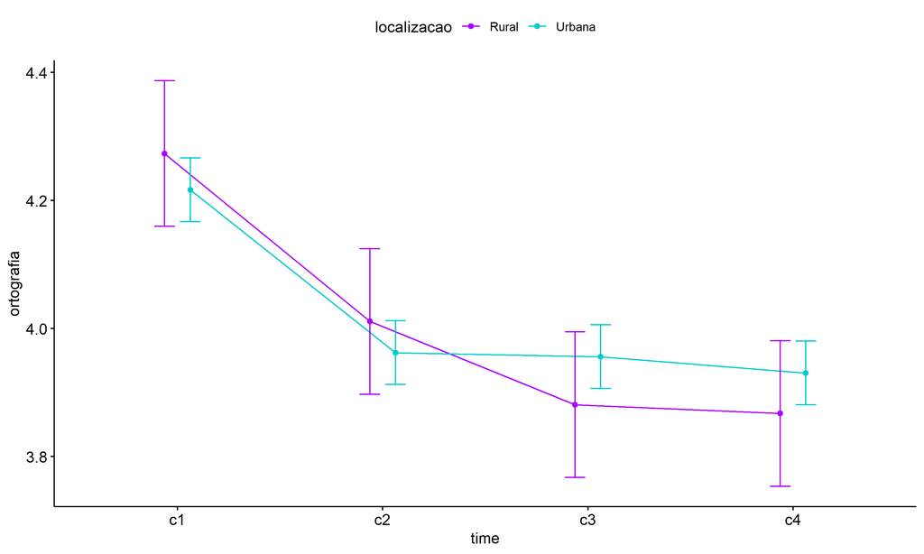

```r
pwc <- add_xy_position(pwc, x = "time", fun = "mean_se", dodge = 0.25)
pd <- position_dodge(width = 0.25)
ggline(emms, x = "time", y = "emmean", color = "localizacao",
       palette = c("#AA00FF","#00CCCC"),
       position = pd, ylab = "ortografia") +
  geom_errorbar(aes(ymin = conf.low, ymax = conf.high, color = localizacao),
                position = pd, width = 0.2) +
  stat_pvalue_manual(pwc, hide.ns = T, tip.length = F, linetype = 1)
```

```r
(pwc <- ldat %>% group_by(localizacao) %>%
    emmeans_test(ortografia ~ time, detailed = T, p.adjust.method = "bonferroni"))
```

```
## # A tibble: 12 × 15
##    localizacao term  .y.        group1 group2 null.value estimate     se    df
##  * <fct>       <chr> <chr>      <chr>  <chr>       <dbl>    <dbl>  <dbl> <dbl>
##  1 Rural       time  ortografia c1     c2              0  0.262   0.0820  4496
##  2 Rural       time  ortografia c1     c3              0  0.392   0.0820  4496
##  3 Rural       time  ortografia c1     c4              0  0.406   0.0820  4496
##  4 Rural       time  ortografia c2     c3              0  0.130   0.0820  4496
##  5 Rural       time  ortografia c2     c4              0  0.144   0.0820  4496
##  6 Rural       time  ortografia c3     c4              0  0.0138  0.0820  4496
##  7 Urbana      time  ortografia c1     c2              0  0.254   0.0359  4496
##  8 Urbana      time  ortografia c1     c3              0  0.260   0.0359  4496
##  9 Urbana      time  ortografia c1     c4              0  0.286   0.0359  4496
## 10 Urbana      time  ortografia c2     c3              0  0.00617 0.0359  4496
## 11 Urbana      time  ortografia c2     c4              0  0.0316  0.0359  4496
## 12 Urbana      time  ortografia c3     c4              0  0.0254  0.0359  4496
## # ℹ 6 more variables: conf.low <dbl>, conf.high <dbl>, statistic <dbl>,
## #   p <dbl>, p.adj <dbl>, p.adj.signif <chr>
```

| localizacao | term | .y. | group1 | group2 | null.value | estimate | se | df | conf.low | conf.high | statistic | p | p.adj | p.adj.signif |
| --- | --- | --- | --- | --- | --- | --- | --- | --- | --- | --- | --- | --- | --- | --- |
| Rural | time | ortografia | c1 | c2 | 0 | 0.262 | 0.082 | 4496 | 0.102 | 0.423 | 3.199 | 0.001 | 0.008 | ** |
| Rural | time | ortografia | c1 | c3 | 0 | 0.392 | 0.082 | 4496 | 0.231 | 0.553 | 4.781 | 0.000 | 0.000 | **** |
| Rural | time | ortografia | c1 | c4 | 0 | 0.406 | 0.082 | 4496 | 0.245 | 0.567 | 4.950 | 0.000 | 0.000 | **** |
| Rural | time | ortografia | c2 | c3 | 0 | 0.130 | 0.082 | 4496 | -0.031 | 0.291 | 1.583 | 0.114 | 0.682 | ns |
| Rural | time | ortografia | c2 | c4 | 0 | 0.144 | 0.082 | 4496 | -0.017 | 0.304 | 1.751 | 0.080 | 0.480 | ns |
| Rural | time | ortografia | c3 | c4 | 0 | 0.014 | 0.082 | 4496 | -0.147 | 0.175 | 0.168 | 0.866 | 1.000 | ns |
| Urbana | time | ortografia | c1 | c2 | 0 | 0.254 | 0.036 | 4496 | 0.184 | 0.325 | 7.083 | 0.000 | 0.000 | **** |
| Urbana | time | ortografia | c1 | c3 | 0 | 0.260 | 0.036 | 4496 | 0.190 | 0.331 | 7.255 | 0.000 | 0.000 | **** |
| Urbana | time | ortografia | c1 | c4 | 0 | 0.286 | 0.036 | 4496 | 0.215 | 0.356 | 7.962 | 0.000 | 0.000 | **** |
| Urbana | time | ortografia | c2 | c3 | 0 | 0.006 | 0.036 | 4496 | -0.064 | 0.077 | 0.172 | 0.864 | 1.000 | ns |
| Urbana | time | ortografia | c2 | c4 | 0 | 0.032 | 0.036 | 4496 | -0.039 | 0.102 | 0.879 | 0.379 | 1.000 | ns |
| Urbana | time | ortografia | c3 | c4 | 0 | 0.025 | 0.036 | 4496 | -0.045 | 0.096 | 0.707 | 0.479 | 1.000 | ns |

```r
(emms <- get_emmeans(pwc))
```

```
## # A tibble: 8 × 8
##   localizacao time  emmean     se    df conf.low conf.high method
##   <fct>       <fct>  <dbl>  <dbl> <dbl>    <dbl>     <dbl> <chr>
## 1 Rural       c1      4.27 0.0580  4496     4.16      4.39 Emmeans test
## 2 Rural       c2      4.01 0.0580  4496     3.90      4.12 Emmeans test
## 3 Rural       c3      3.88 0.0580  4496     3.77      3.99 Emmeans test
## 4 Rural       c4      3.87 0.0580  4496     3.75      3.98 Emmeans test
## 5 Urbana      c1      4.22 0.0254  4496     4.17      4.27 Emmeans test
## 6 Urbana      c2      3.96 0.0254  4496     3.91      4.01 Emmeans test
## 7 Urbana      c3      3.96 0.0254  4496     3.91      4.01 Emmeans test
## 8 Urbana      c4      3.93 0.0254  4496     3.88      3.98 Emmeans test
```

| localizacao | time | emmean | se | df | conf.low | conf.high | method |
| --- | --- | --- | --- | --- | --- | --- | --- |
| Rural | c1 | 4.273 | 0.058 | 4496 | 4.160 | 4.387 | Emmeans test |
| Rural | c2 | 4.011 | 0.058 | 4496 | 3.897 | 4.125 | Emmeans test |
| Rural | c3 | 3.881 | 0.058 | 4496 | 3.767 | 3.995 | Emmeans test |
| Rural | c4 | 3.867 | 0.058 | 4496 | 3.754 | 3.981 | Emmeans test |
| Urbana | c1 | 4.217 | 0.025 | 4496 | 4.167 | 4.266 | Emmeans test |
| Urbana | c2 | 3.962 | 0.025 | 4496 | 3.912 | 4.012 | Emmeans test |
| Urbana | c3 | 3.956 | 0.025 | 4496 | 3.906 | 4.006 | Emmeans test |
| Urbana | c4 | 3.931 | 0.025 | 4496 | 3.881 | 3.980 | Emmeans test |

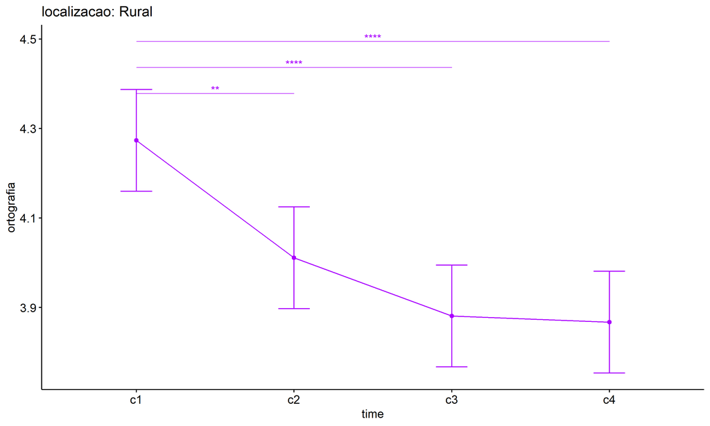

```r
emms.gg <- emms[which(emms$localizacao == "Rural"),]
if (nrow(emms.gg) > 0)
  ggline(emms.gg, x = "time", y = "emmean", color = "#AA00FF", ylab = "ortografia") +
    geom_errorbar(aes(ymin = conf.low, ymax = conf.high),
                  width = 0.2, color = "#AA00FF") +
    stat_pvalue_manual(
      add_xy_position(pwc[which(pwc$localizacao == "Rural"),],
                      x = "time", fun = "mean_se"),
      hide.ns = T, color = "#AA00FF", tip.length = F) +
    labs(title = "localizacao: Rural")+
    theme(legend.text = element_blank())
```

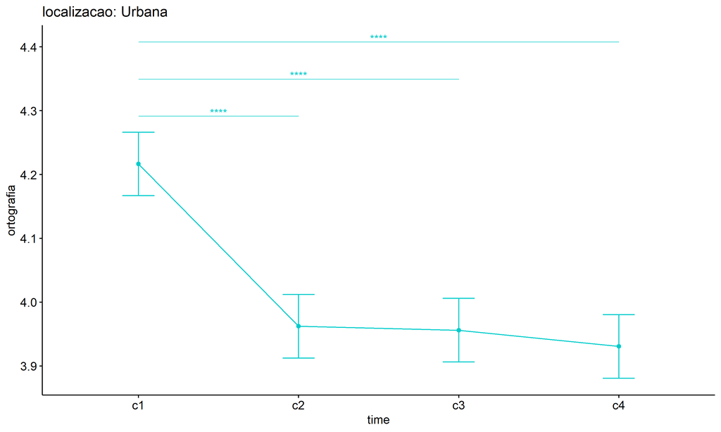

```r
emms.gg <- emms[which(emms$localizacao == "Urbana"),]
if (nrow(emms.gg) > 0)
  ggline(emms.gg, x = "time", y = "emmean", color = "#00CCCC", ylab = "ortografia") +
    geom_errorbar(aes(ymin = conf.low, ymax = conf.high),
                  width = 0.2, color = "#00CCCC") +
    stat_pvalue_manual(
      add_xy_position(pwc[which(pwc$localizacao == "Urbana"),],
                      x = "time", fun = "mean_se"),
      hide.ns = T, color = "#00CCCC", tip.length = F) +
    labs(title = "localizacao: Urbana")+
    theme(legend.text = element_blank())
```

## PairWise Computation after removing non.normal data

```r
if (length(non.ids) > 0)
  (pwc2 <- ldat2 %>% group_by(time) %>%
     emmeans_test(ortografia ~ localizacao, detailed = T, p.adjust.method = "bonferroni"))
```

```r
if (length(non.ids) > 0)
  (emms2 <- get_emmeans(pwc2))
```

```r
if (length(non.ids) > 0) {
  pwc2 <- add_xy_position(pwc2, x = "time", fun = "mean_se", dodge = 0.25)
  pd2 <- position_dodge(width = 0.25)

  ggline(emms2, x = "time", y = "emmean", color = "localizacao",
         palette = c("#AA00FF","#00CCCC"),
         position = pd, ylab = "ortografia") +
    geom_errorbar(aes(ymin = conf.low, ymax = conf.high, color = localizacao),
                position = pd, width = 0.2) +
    stat_pvalue_manual(pwc2, hide.ns = T, tip.length = F, linetype = 1)
}
```

```r
if (length(non.ids) > 0)
  (pwc2 <- ldat2 %>% group_by(localizacao) %>%
     emmeans_test(ortografia ~ time, detailed = T, p.adjust.method = "bonferroni"))
```

```r
if (length(non.ids) > 0)
  (emms2 <- get_emmeans(pwc2))
```

```r
if (length(non.ids) > 0) {
  emms.gg <- emms2[which(emms2$localizacao == "Rural"),]
  if (nrow(emms.gg) > 0)
    ggline(emms.gg, x = "time", y = "emmean", color = "#AA00FF", ylab = "ortografia") +
    geom_errorbar(aes(ymin = conf.low, ymax = conf.high),
                  width = 0.2, color = "#AA00FF") +
    stat_pvalue_manual(
      add_xy_position(pwc[which(pwc$localizacao == "Rural"),],
                      x = "time", fun = "mean_se"),
      hide.ns = T, color = "#AA00FF", tip.length = F) +
    labs(title = "localizacao: Rural") +
    theme(legend.text = element_blank())
}
```

```r
if (length(non.ids) > 0) {
  emms.gg <- emms2[which(emms2$localizacao == "Urbana"),]
  if (nrow(emms.gg) > 0)
    ggline(emms.gg, x = "time", y = "emmean", color = "#00CCCC", ylab = "ortografia") +
    geom_errorbar(aes(ymin = conf.low, ymax = conf.high),
                  width = 0.2, color = "#00CCCC") +
    stat_pvalue_manual(
      add_xy_position(pwc[which(pwc$localizacao == "Urbana"),],
                      x = "time", fun = "mean_se"),
      hide.ns = T, color = "#00CCCC", tip.length = F) +
    labs(title = "localizacao: Urbana") +
    theme(legend.text = element_blank())
}
```

# ANOVA: ortografia ~ time*regiao + Error(id/time)

## Data Preparation

```r
data <- edat[,c("aluno_id","regiao","ciclo","ortografia")]
data <- data[data$ciclo %in% c("Primeiro Ciclo","Segundo Ciclo","Terceiro Ciclo","Quarto Ciclo"),]
data$ciclo <- factor(data$ciclo, c("Primeiro Ciclo","Segundo Ciclo","Terceiro Ciclo","Quarto Ciclo"))
data <- unique(data)

wdat <- spread(data, ciclo, ortografia)
wdat <- wdat[complete.cases(wdat),]
colnames(wdat) <- c("id","regiao","c1","c2","c3","c4")

ldat <- gather(wdat, key = time, value = ortografia, c1,c2,c3,c4) %>%
  convert_as_factor(id, time)
ldat <- remove_group_data(ldat, "ortografia", c("time", "regiao"), n.limit = 30)
ldat$regiao <- factor(ldat$regiao, sort(unique(ldat$regiao)))
```

### Check assumptions: Identifying Outliers

```r
outliers <- identify_outliers(group_by(ldat, time, regiao), ortografia)
(outliers <- outliers[outliers$is.extreme == T,])
```

```
## # A tibble: 19 × 6
##    regiao time  id                   ortografia is.outlier is.extreme
##    <fct>  <fct> <fct>                     <dbl> <lgl>      <lgl>
##  1 Norte  c1    0Yib1O7JnhfpPr2v5QTr       4    TRUE       TRUE
##  2 Norte  c1    2hRYk5Ant545stWX17Xb       4.5  TRUE       TRUE
##  3 Norte  c1    5AeP0IQ84CerIQVenp2G       4    TRUE       TRUE
##  4 Norte  c1    5JAU6KgxtPpvOFcIs6rW       4    TRUE       TRUE
##  5 Norte  c1    7WTXqn4B7aG5f8XMF9ow       4    TRUE       TRUE
##  6 Norte  c1    knPmAE3VLSnirKKQgoQL       3.67 TRUE       TRUE
##  7 Norte  c1    OqRUhx1jhRZAcU4L57VG       3    TRUE       TRUE
##  8 Norte  c1    p1VserpteNOF4vPAJcXk       4.5  TRUE       TRUE
##  9 Norte  c1    p60GU5cf9uaftl79CXwQ       4.5  TRUE       TRUE
## 10 Norte  c1    r0MWkZrx9MvBa9Tx8Okb       4    TRUE       TRUE
## 11 Norte  c1    RG5EPSzbZxigtb7hYi0o       3.5  TRUE       TRUE
## 12 Norte  c1    sqpv9PeCZ7wwRh2srw1I       4    TRUE       TRUE
## 13 Norte  c1    T7LyWcmMC7ND1ybbKOSC       3.5  TRUE       TRUE
## 14 Norte  c1    uvbG68yspOWVeG7vqGSx       4.5  TRUE       TRUE
## 15 Norte  c1    XNUevhFi1klsxXnVIzQh       4    TRUE       TRUE
## 16 Norte  c1    XwEKXhJtekbFWF6eQECC       3    TRUE       TRUE
## 17 Norte  c1    YSmpjBm1uxtGCFC4GrkG       4    TRUE       TRUE
## 18 Norte  c1    z8HoZfofL0zC9Rg4P8Kj       4    TRUE       TRUE
## 19 Norte  c1    zkW6c2m0BkbGXx8JpERU       3    TRUE       TRUE
```

| regiao | time | id | ortografia | is.outlier | is.extreme |
| --- | --- | --- | --- | --- | --- |
| Norte | c1 | 0Yib1O7JnhfpPr2v5QTr | 4.000 | TRUE | TRUE |
| Norte | c1 | 2hRYk5Ant545stWX17Xb | 4.500 | TRUE | TRUE |
| Norte | c1 | 5AeP0IQ84CerIQVenp2G | 4.000 | TRUE | TRUE |
| Norte | c1 | 5JAU6KgxtPpvOFcIs6rW | 4.000 | TRUE | TRUE |
| Norte | c1 | 7WTXqn4B7aG5f8XMF9ow | 4.000 | TRUE | TRUE |
| Norte | c1 | knPmAE3VLSnirKKQgoQL | 3.667 | TRUE | TRUE |
| Norte | c1 | OqRUhx1jhRZAcU4L57VG | 3.000 | TRUE | TRUE |
| Norte | c1 | p1VserpteNOF4vPAJcXk | 4.500 | TRUE | TRUE |
| Norte | c1 | p60GU5cf9uaftl79CXwQ | 4.500 | TRUE | TRUE |
| Norte | c1 | r0MWkZrx9MvBa9Tx8Okb | 4.000 | TRUE | TRUE |
| Norte | c1 | RG5EPSzbZxigtb7hYi0o | 3.500 | TRUE | TRUE |
| Norte | c1 | sqpv9PeCZ7wwRh2srw1I | 4.000 | TRUE | TRUE |
| Norte | c1 | T7LyWcmMC7ND1ybbKOSC | 3.500 | TRUE | TRUE |
| Norte | c1 | uvbG68yspOWVeG7vqGSx | 4.500 | TRUE | TRUE |
| Norte | c1 | XNUevhFi1klsxXnVIzQh | 4.000 | TRUE | TRUE |
| Norte | c1 | XwEKXhJtekbFWF6eQECC | 3.000 | TRUE | TRUE |
| Norte | c1 | YSmpjBm1uxtGCFC4GrkG | 4.000 | TRUE | TRUE |
| Norte | c1 | z8HoZfofL0zC9Rg4P8Kj | 4.000 | TRUE | TRUE |
| Norte | c1 | zkW6c2m0BkbGXx8JpERU | 3.000 | TRUE | TRUE |

### Check assumptions: Normality Test

```r
(normality.df <- normality.test.per.groups(ldat, "ortografia", c("time", "regiao")))
```

```
##           var   variable time       regiao   n    skewness   kurtosis symmetry
## 1  ortografia ortografia   c1 Centro-Oeste  48 -0.17425164 -1.5406062      YES
## 2  ortografia ortografia   c1     Nordeste 545 -0.50622443 -1.2618648       NO
## 3  ortografia ortografia   c1        Norte  78 -1.84210920  2.3257696       NO
## 4  ortografia ortografia   c1      Sudeste 393 -0.31248105 -1.3473877      YES
## 5  ortografia ortografia   c1          Sul  62  0.12665928 -1.2912610      YES
## 6  ortografia ortografia   c2 Centro-Oeste  48 -0.15091928 -1.4369988      YES
## 7  ortografia ortografia   c2     Nordeste 545 -0.08238349 -1.4470866      YES
## 8  ortografia ortografia   c2        Norte  78  0.24882396 -1.5596637      YES
## 9  ortografia ortografia   c2      Sudeste 393  0.17190334 -1.3652243      YES
## 10 ortografia ortografia   c2          Sul  62 -0.01352076 -1.7552516      YES
## 11 ortografia ortografia   c3 Centro-Oeste  48 -0.52430248 -1.0410448       NO
## 12 ortografia ortografia   c3     Nordeste 545  0.02496933 -1.3704417      YES
## 13 ortografia ortografia   c3        Norte  78 -0.39662940 -1.2968020      YES
## 14 ortografia ortografia   c3      Sudeste 393  0.20398933 -1.3007648      YES
```

[output cut: 27 more lines]

| var | variable | time | regiao | n | skewness | kurtosis | symmetry | statistic | method | p | p.signif | normality |
| --- | --- | --- | --- | --- | --- | --- | --- | --- | --- | --- | --- | --- |
| ortografia | ortografia | c1 | Centro-Oeste | 48 | -0.174 | -1.541 | YES | 0.840 | Shapiro-Wilk | 0.000 | **** | NO |
| ortografia | ortografia | c1 | Nordeste | 545 | -0.506 | -1.262 | NO | 573.238 | D’Agostino | 0.000 | **** | - |
| ortografia | ortografia | c1 | Norte | 78 | -1.842 | 2.326 | NO | 36.418 | D’Agostino | 0.000 | **** | NO |
| ortografia | ortografia | c1 | Sudeste | 393 | -0.312 | -1.347 | YES | 847.451 | D’Agostino | 0.000 | **** | - |
| ortografia | ortografia | c1 | Sul | 62 | 0.127 | -1.291 | YES | 19.079 | D’Agostino | 0.000 | **** | NO |
| ortografia | ortografia | c2 | Centro-Oeste | 48 | -0.151 | -1.437 | YES | 0.854 | Shapiro-Wilk | 0.000 | **** | NO |
| ortografia | ortografia | c2 | Nordeste | 545 | -0.082 | -1.447 | YES | 6767.150 | D’Agostino | 0.000 | **** | - |
| ortografia | ortografia | c2 | Norte | 78 | 0.249 | -1.560 | YES | 133.517 | D’Agostino | 0.000 | **** | NO |
| ortografia | ortografia | c2 | Sudeste | 393 | 0.172 | -1.365 | YES | 1120.446 | D’Agostino | 0.000 | **** | - |
| ortografia | ortografia | c2 | Sul | 62 | -0.014 | -1.755 | YES | 527.551 | D’Agostino | 0.000 | **** | NO |
| ortografia | ortografia | c3 | Centro-Oeste | 48 | -0.524 | -1.041 | NO | 0.835 | Shapiro-Wilk | 0.000 | **** | NO |
| ortografia | ortografia | c3 | Nordeste | 545 | 0.025 | -1.370 | YES | 2933.766 | D’Agostino | 0.000 | **** | - |
| ortografia | ortografia | c3 | Norte | 78 | -0.397 | -1.297 | YES | 31.493 | D’Agostino | 0.000 | **** | NO |
| ortografia | ortografia | c3 | Sudeste | 393 | 0.204 | -1.301 | YES | 488.111 | D’Agostino | 0.000 | **** | - |
| ortografia | ortografia | c3 | Sul | 62 | 0.684 | -0.868 | NO | 8.259 | D’Agostino | 0.016 | * | NO |
| ortografia | ortografia | c4 | Centro-Oeste | 48 | -0.327 | -1.519 | YES | 0.796 | Shapiro-Wilk | 0.000 | **** | NO |
| ortografia | ortografia | c4 | Nordeste | 545 | 0.016 | -1.414 | YES | 12420.391 | D’Agostino | 0.000 | **** | - |
| ortografia | ortografia | c4 | Norte | 78 | -0.151 | -1.049 | YES | 10.214 | D’Agostino | 0.006 | ** | NO |
| ortografia | ortografia | c4 | Sudeste | 393 | 0.277 | -1.409 | YES | 4348.503 | D’Agostino | 0.000 | **** | - |
| ortografia | ortografia | c4 | Sul | 62 | 0.454 | -1.177 | YES | 14.149 | D’Agostino | 0.001 | *** | NO |

```r
(non.ids <- unique(do.call(
  c, lapply(which(normality.df$normality == 'NO'), FUN = function(i) {
  idx = which(ldat$time == normality.df$time[i] &
                ldat$regiao == normality.df$regiao[i])
  getNonNormal(ldat$"ortografia"[idx], ldat$id[idx])
}))))
```

```
##   [1] "XPDsLJmk5xRPBBQTOEFf" "3fTmP8cTTJq8WUIEU0Xl" "uqX7aPoHn8tMaKAp9y3I"
##   [4] "3mBgwnK6Vvt3dkhVOTAf" "sV9mhY7G3TGd1YYuX6Tn" "8p6QYQYkfhR3QOACXZvj"
##   [7] "q2OHBM4WxXWQPFhPS0zC" "9jd1C85ixCoJf3EINYfx" "oB5KNHL8aUZyGZK3jNIP"
##  [10] "D5ZRR3Ps7EtPoEi233KU" "LC1uBEBe3hZn8Q1mQe7A" "gzBUwnjjYHnioTnd4stC"
##  [13] "KPMkDhksSiEWVEIUT1LG" "i5Gd55pjKNa1DpzdbUJf" "IJtLVa8jEy3VAWIMlskm"
##  [16] "LSOWrW4dOhXZ9uMW17va" "sXB3m8f7P40lRXYwY22p" "H5F4r5nnGQTG1FzfyxrY"
##  [19] "edONhkMBY1DIsXNuuodO" "18EWxrJZtjBVpzckkv21" "vSolOA78V6l7oYJ1h4LA"
##  [22] "atydp19vM0PjiOQCWemR" "OqRUhx1jhRZAcU4L57VG" "XwEKXhJtekbFWF6eQECC"
##  [25] "zkW6c2m0BkbGXx8JpERU" "RG5EPSzbZxigtb7hYi0o" "T7LyWcmMC7ND1ybbKOSC"
##  [28] "knPmAE3VLSnirKKQgoQL" "1M4bMmWG0ZmjAN8eePwD" "5dTW1T1ER6Ig8ZOhKC2q"
##  [31] "ul0PgHFaS5fXGvdx1O9S" "5LQ0t7JuIopawwuHaYqd" "9w7fsQmTt0KXHULPLQeu"
##  [34] "caJZotxjZgCkmAoI7E6m" "DKEsQosaERswlkB803hB" "sffGDKv6xIaW7M5huGEp"
##  [37] "EzAC2fhSVjbiGVreVQkr" "f8lbqRJeObyskQrt1pLC" "WshMGLj49S97LCd6BetO"
##  [40] "WCSObSsiS3xWwGKtJ3Wu" "dKIqav6TRc1lClMWW6hS" "q1RelulkOweB4lCMWfxy"
##  [43] "ZwZKuoXF7JaYzVxPoHvk" "ZDsN200AOSuZkmxgcc8n" "1Z1Qz8zDaMkaAz1Ah80K"
```

[output cut: 40 more lines]

```r
if (length(non.ids) > 0)
  ldat2 <- ldat[!ldat$id %in% non.ids,]
```

### Summary Statistics

```r
(sdat <- ldat %>% group_by(time, regiao) %>%
   get_summary_stats(ortografia, type = "mean_sd"))
```

```
## # A tibble: 20 × 6
##    regiao       time  variable       n  mean    sd
##    <fct>        <fct> <fct>      <dbl> <dbl> <dbl>
##  1 Centro-Oeste c1    ortografia    48  4.08 0.794
##  2 Nordeste     c1    ortografia   545  4.25 0.789
##  3 Norte        c1    ortografia    78  4.73 0.54
##  4 Sudeste      c1    ortografia   393  4.16 0.78
##  5 Sul          c1    ortografia    62  3.92 0.748
##  6 Centro-Oeste c2    ortografia    48  4.05 0.773
##  7 Nordeste     c2    ortografia   545  4.02 0.793
##  8 Norte        c2    ortografia    78  3.88 0.823
##  9 Sudeste      c2    ortografia   393  3.90 0.772
## 10 Sul          c2    ortografia    62  4.00 0.884
## 11 Centro-Oeste c3    ortografia    48  4.23 0.729
## 12 Nordeste     c3    ortografia   545  3.98 0.767
## 13 Norte        c3    ortografia    78  4.20 0.762
## 14 Sudeste      c3    ortografia   393  3.86 0.754
## 15 Sul          c3    ortografia    62  3.64 0.714
## 16 Centro-Oeste c4    ortografia    48  4.16 0.826
## 17 Nordeste     c4    ortografia   545  3.97 0.776
## 18 Norte        c4    ortografia    78  4.18 0.669
## 19 Sudeste      c4    ortografia   393  3.84 0.786
## 20 Sul          c4    ortografia    62  3.52 0.572
```

| regiao | time | variable | n | mean | sd |
| --- | --- | --- | --- | --- | --- |
| Centro-Oeste | c1 | ortografia | 48 | 4.083 | 0.794 |
| Nordeste | c1 | ortografia | 545 | 4.252 | 0.789 |
| Norte | c1 | ortografia | 78 | 4.726 | 0.540 |
| Sudeste | c1 | ortografia | 393 | 4.155 | 0.780 |
| Sul | c1 | ortografia | 62 | 3.919 | 0.748 |
| Centro-Oeste | c2 | ortografia | 48 | 4.047 | 0.773 |
| Nordeste | c2 | ortografia | 545 | 4.023 | 0.793 |
| Norte | c2 | ortografia | 78 | 3.878 | 0.823 |
| Sudeste | c2 | ortografia | 393 | 3.901 | 0.772 |
| Sul | c2 | ortografia | 62 | 3.999 | 0.884 |
| Centro-Oeste | c3 | ortografia | 48 | 4.229 | 0.729 |
| Nordeste | c3 | ortografia | 545 | 3.980 | 0.767 |
| Norte | c3 | ortografia | 78 | 4.205 | 0.762 |
| Sudeste | c3 | ortografia | 393 | 3.856 | 0.754 |
| Sul | c3 | ortografia | 62 | 3.637 | 0.714 |
| Centro-Oeste | c4 | ortografia | 48 | 4.156 | 0.826 |
| Nordeste | c4 | ortografia | 545 | 3.966 | 0.776 |
| Norte | c4 | ortografia | 78 | 4.179 | 0.669 |
| Sudeste | c4 | ortografia | 393 | 3.841 | 0.786 |
| Sul | c4 | ortografia | 62 | 3.516 | 0.572 |

```r
if (length(non.ids) > 0)
  (sdat <- ldat2 %>% group_by(time, regiao) %>%
      get_summary_stats(ortografia, type = "mean_sd"))
```

```
## # A tibble: 20 × 6
##    regiao       time  variable       n  mean     sd
##    <fct>        <fct> <fct>      <dbl> <dbl>  <dbl>
##  1 Centro-Oeste c1    ortografia     1  4.5  NA
##  2 Nordeste     c1    ortografia   545  4.25  0.789
##  3 Norte        c1    ortografia    19  4.84  0.375
##  4 Sudeste      c1    ortografia   393  4.16  0.78
##  5 Sul          c1    ortografia     5  4.4   0.894
##  6 Centro-Oeste c2    ortografia     1  4.5  NA
##  7 Nordeste     c2    ortografia   545  4.02  0.793
##  8 Norte        c2    ortografia    19  4.05  0.575
##  9 Sudeste      c2    ortografia   393  3.90  0.772
## 10 Sul          c2    ortografia     5  4.13  0.794
## 11 Centro-Oeste c3    ortografia     1  3.5  NA
## 12 Nordeste     c3    ortografia   545  3.98  0.767
## 13 Norte        c3    ortografia    19  4.05  0.724
## 14 Sudeste      c3    ortografia   393  3.86  0.754
## 15 Sul          c3    ortografia     5  4.2   0.837
## 16 Centro-Oeste c4    ortografia     1  4.5  NA
## 17 Nordeste     c4    ortografia   545  3.97  0.776
## 18 Norte        c4    ortografia    19  4.21  0.631
## 19 Sudeste      c4    ortografia   393  3.84  0.786
## 20 Sul          c4    ortografia     5  4     0.354
```

| regiao | time | variable | n | mean | sd |
| --- | --- | --- | --- | --- | --- |
| Centro-Oeste | c1 | ortografia | 1 | 4.500 | NA |
| Nordeste | c1 | ortografia | 545 | 4.252 | 0.789 |
| Norte | c1 | ortografia | 19 | 4.842 | 0.375 |
| Sudeste | c1 | ortografia | 393 | 4.155 | 0.780 |
| Sul | c1 | ortografia | 5 | 4.400 | 0.894 |
| Centro-Oeste | c2 | ortografia | 1 | 4.500 | NA |
| Nordeste | c2 | ortografia | 545 | 4.023 | 0.793 |
| Norte | c2 | ortografia | 19 | 4.053 | 0.575 |
| Sudeste | c2 | ortografia | 393 | 3.901 | 0.772 |
| Sul | c2 | ortografia | 5 | 4.133 | 0.794 |
| Centro-Oeste | c3 | ortografia | 1 | 3.500 | NA |
| Nordeste | c3 | ortografia | 545 | 3.980 | 0.767 |
| Norte | c3 | ortografia | 19 | 4.053 | 0.724 |
| Sudeste | c3 | ortografia | 393 | 3.856 | 0.754 |
| Sul | c3 | ortografia | 5 | 4.200 | 0.837 |
| Centro-Oeste | c4 | ortografia | 1 | 4.500 | NA |
| Nordeste | c4 | ortografia | 545 | 3.966 | 0.776 |
| Norte | c4 | ortografia | 19 | 4.211 | 0.631 |
| Sudeste | c4 | ortografia | 393 | 3.841 | 0.786 |
| Sul | c4 | ortografia | 5 | 4.000 | 0.354 |

## ANOVA Computation

```r
(res.aov <- anova_test(ldat, dv = ortografia, wid = id, between = regiao, within = time))
```

```
## ANOVA Table (type III tests)
##
## $ANOVA
##        Effect DFn  DFd      F        p p<.05   ges
## 1      regiao   4 1121 13.950 4.12e-11     * 0.017
## 2        time   3 3363 16.437 1.33e-10     * 0.009
## 3 regiao:time  12 3363  4.285 8.90e-07     * 0.010
##
## $`Mauchly's Test for Sphericity`
##        Effect     W     p p<.05
## 1        time 0.989 0.031     *
## 2 regiao:time 0.989 0.031     *
##
## $`Sphericity Corrections`
##        Effect   GGe        DF[GG]    p[GG] p[GG]<.05   HFe         DF[HF]
## 1        time 0.992  2.98, 3337.7 1.54e-10         * 0.995  2.99, 3347.57
## 2 regiao:time 0.992 11.91, 3337.7 9.69e-07         * 0.995 11.94, 3347.57
##      p[HF] p[HF]<.05
## 1 1.45e-10         *
## 2 9.38e-07         *
```

| Effect | DFn | DFd | F | p | p<.05 | ges |
| --- | --- | --- | --- | --- | --- | --- |
| regiao | 4 | 1121 | 13.950 | 0 | * | 0.017 |
| time | 3 | 3363 | 16.437 | 0 | * | 0.009 |
| regiao:time | 12 | 3363 | 4.285 | 0 | * | 0.010 |

| Effect | W | p | p<.05 |
| --- | --- | --- | --- |
| time | 0.989 | 0.031 | * |
| regiao:time | 0.989 | 0.031 | * |

| Effect | GGe | DF $$GG$$ | p $$GG$$ | p $$GG$$ <.05 | HFe | DF $$HF$$ | p $$HF$$ | p $$HF$$ <.05 |
| --- | --- | --- | --- | --- | --- | --- | --- | --- |
| time | 0.992 | 2.98, 3337.7 | 0 | * | 0.995 | 2.99, 3347.57 | 0 | * |
| regiao:time | 0.992 | 11.91, 3337.7 | 0 | * | 0.995 | 11.94, 3347.57 | 0 | * |

## ANOVA Computation after removing non.normal data

```r
if (length(non.ids) > 0)
  (res.aov2 <- anova_test(ldat2, dv = ortografia, wid = id, between = regiao , within = time))
```

```
## ANOVA Table (type III tests)
##
## $ANOVA
##        Effect DFn  DFd     F        p p<.05   ges
## 1      regiao   4  958 5.474 0.000233     * 0.008
## 2        time   3 2874 1.767 0.151000       0.001
## 3 regiao:time  12 2874 0.714 0.739000       0.002
##
## $`Mauchly's Test for Sphericity`
##        Effect     W     p p<.05
## 1        time 0.984 0.009     *
## 2 regiao:time 0.984 0.009     *
##
## $`Sphericity Corrections`
##        Effect   GGe         DF[GG] p[GG] p[GG]<.05   HFe         DF[HF] p[HF]
## 1        time 0.989  2.97, 2842.09 0.152           0.992  2.98, 2851.89 0.152
## 2 regiao:time 0.989 11.87, 2842.09 0.738           0.992 11.91, 2851.89 0.738
##   p[HF]<.05
## 1
## 2
```

| Effect | DFn | DFd | F | p | p<.05 | ges |
| --- | --- | --- | --- | --- | --- | --- |
| regiao | 4 | 958 | 5.474 | 0.000 | * | 0.008 |
| time | 3 | 2874 | 1.767 | 0.151 |  | 0.001 |
| regiao:time | 12 | 2874 | 0.714 | 0.739 |  | 0.002 |

| Effect | W | p | p<.05 |
| --- | --- | --- | --- |
| time | 0.984 | 0.009 | * |
| regiao:time | 0.984 | 0.009 | * |

| Effect | GGe | DF $$GG$$ | p $$GG$$ | p $$GG$$ <.05 | HFe | DF $$HF$$ | p $$HF$$ | p $$HF$$ <.05 |
| --- | --- | --- | --- | --- | --- | --- | --- | --- |
| time | 0.989 | 2.97, 2842.09 | 0.152 |  | 0.992 | 2.98, 2851.89 | 0.152 |  |
| regiao:time | 0.989 | 11.87, 2842.09 | 0.738 |  | 0.992 | 11.91, 2851.89 | 0.738 |  |

## PairWise Computation

```r
(pwc <- ldat %>% group_by(time) %>%
   emmeans_test(ortografia ~ regiao, detailed = T, p.adjust.method = "bonferroni"))
```

[output not shown]

```r
(emms <- get_emmeans(pwc))
```

```
## # A tibble: 20 × 8
##    time  regiao       emmean     se    df conf.low conf.high method
##    <fct> <fct>         <dbl>  <dbl> <dbl>    <dbl>     <dbl> <chr>
##  1 c1    Centro-Oeste   4.08 0.111   4484     3.87      4.30 Emmeans test
##  2 c1    Nordeste       4.25 0.0330  4484     4.19      4.32 Emmeans test
##  3 c1    Norte          4.73 0.0873  4484     4.56      4.90 Emmeans test
##  4 c1    Sudeste        4.16 0.0389  4484     4.08      4.23 Emmeans test
##  5 c1    Sul            3.92 0.0980  4484     3.73      4.11 Emmeans test
##  6 c2    Centro-Oeste   4.05 0.111   4484     3.83      4.27 Emmeans test
##  7 c2    Nordeste       4.02 0.0330  4484     3.96      4.09 Emmeans test
##  8 c2    Norte          3.88 0.0873  4484     3.71      4.05 Emmeans test
##  9 c2    Sudeste        3.90 0.0389  4484     3.82      3.98 Emmeans test
## 10 c2    Sul            4.00 0.0980  4484     3.81      4.19 Emmeans test
## 11 c3    Centro-Oeste   4.23 0.111   4484     4.01      4.45 Emmeans test
## 12 c3    Nordeste       3.98 0.0330  4484     3.92      4.04 Emmeans test
## 13 c3    Norte          4.21 0.0873  4484     4.03      4.38 Emmeans test
## 14 c3    Sudeste        3.86 0.0389  4484     3.78      3.93 Emmeans test
## 15 c3    Sul            3.64 0.0980  4484     3.45      3.83 Emmeans test
## 16 c4    Centro-Oeste   4.16 0.111   4484     3.94      4.37 Emmeans test
## 17 c4    Nordeste       3.97 0.0330  4484     3.90      4.03 Emmeans test
## 18 c4    Norte          4.18 0.0873  4484     4.01      4.35 Emmeans test
## 19 c4    Sudeste        3.84 0.0389  4484     3.76      3.92 Emmeans test
## 20 c4    Sul            3.52 0.0980  4484     3.32      3.71 Emmeans test
```

| time | regiao | emmean | se | df | conf.low | conf.high | method |
| --- | --- | --- | --- | --- | --- | --- | --- |
| c1 | Centro-Oeste | 4.083 | 0.111 | 4484 | 3.865 | 4.302 | Emmeans test |
| c1 | Nordeste | 4.252 | 0.033 | 4484 | 4.188 | 4.317 | Emmeans test |
| c1 | Norte | 4.726 | 0.087 | 4484 | 4.555 | 4.898 | Emmeans test |
| c1 | Sudeste | 4.155 | 0.039 | 4484 | 4.079 | 4.231 | Emmeans test |
| c1 | Sul | 3.919 | 0.098 | 4484 | 3.727 | 4.111 | Emmeans test |
| c2 | Centro-Oeste | 4.047 | 0.111 | 4484 | 3.829 | 4.265 | Emmeans test |
| c2 | Nordeste | 4.023 | 0.033 | 4484 | 3.958 | 4.088 | Emmeans test |
| c2 | Norte | 3.878 | 0.087 | 4484 | 3.707 | 4.049 | Emmeans test |
| c2 | Sudeste | 3.901 | 0.039 | 4484 | 3.825 | 3.977 | Emmeans test |
| c2 | Sul | 3.999 | 0.098 | 4484 | 3.807 | 4.191 | Emmeans test |
| c3 | Centro-Oeste | 4.229 | 0.111 | 4484 | 4.011 | 4.447 | Emmeans test |
| c3 | Nordeste | 3.980 | 0.033 | 4484 | 3.915 | 4.045 | Emmeans test |
| c3 | Norte | 4.205 | 0.087 | 4484 | 4.034 | 4.376 | Emmeans test |
| c3 | Sudeste | 3.856 | 0.039 | 4484 | 3.780 | 3.933 | Emmeans test |
| c3 | Sul | 3.637 | 0.098 | 4484 | 3.445 | 3.829 | Emmeans test |
| c4 | Centro-Oeste | 4.156 | 0.111 | 4484 | 3.938 | 4.375 | Emmeans test |
| c4 | Nordeste | 3.966 | 0.033 | 4484 | 3.901 | 4.031 | Emmeans test |
| c4 | Norte | 4.179 | 0.087 | 4484 | 4.008 | 4.351 | Emmeans test |
| c4 | Sudeste | 3.841 | 0.039 | 4484 | 3.765 | 3.917 | Emmeans test |
| c4 | Sul | 3.516 | 0.098 | 4484 | 3.324 | 3.708 | Emmeans test |

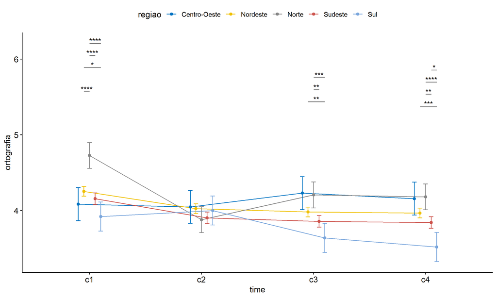

```r
pwc <- add_xy_position(pwc, x = "time", fun = "mean_se", dodge = 0.25)
pd <- position_dodge(width = 0.25)
ggline(emms, x = "time", y = "emmean", color = "regiao",
       palette = c("#0073C2FF","#EFC000FF","#868686FF","#CD534CFF","#7AA6DCFF"),
       position = pd, ylab = "ortografia") +
  geom_errorbar(aes(ymin = conf.low, ymax = conf.high, color = regiao),
                position = pd, width = 0.2) +
  stat_pvalue_manual(pwc, hide.ns = T, tip.length = F, linetype = 1)
```

```r
(pwc <- ldat %>% group_by(regiao) %>%
    emmeans_test(ortografia ~ time, detailed = T, p.adjust.method = "bonferroni"))
```

```
## # A tibble: 30 × 15
##    regiao    term  .y.   group1 group2 null.value estimate     se    df conf.low
##  * <fct>     <chr> <chr> <chr>  <chr>       <dbl>    <dbl>  <dbl> <dbl>    <dbl>
##  1 Centro-O… time  orto… c1     c2              0   0.0365 0.157   4484  -0.272
##  2 Centro-O… time  orto… c1     c3              0  -0.146  0.157   4484  -0.454
##  3 Centro-O… time  orto… c1     c4              0  -0.0729 0.157   4484  -0.382
##  4 Centro-O… time  orto… c2     c3              0  -0.182  0.157   4484  -0.491
##  5 Centro-O… time  orto… c2     c4              0  -0.109  0.157   4484  -0.418
##  6 Centro-O… time  orto… c3     c4              0   0.0729 0.157   4484  -0.236
##  7 Nordeste  time  orto… c1     c2              0   0.229  0.0467  4484   0.138
##  8 Nordeste  time  orto… c1     c3              0   0.272  0.0467  4484   0.181
##  9 Nordeste  time  orto… c1     c4              0   0.286  0.0467  4484   0.195
## 10 Nordeste  time  orto… c2     c3              0   0.0433 0.0467  4484  -0.0483
## # ℹ 20 more rows
## # ℹ 5 more variables: conf.high <dbl>, statistic <dbl>, p <dbl>, p.adj <dbl>,
## #   p.adj.signif <chr>
```

| regiao | term | .y. | group1 | group2 | null.value | estimate | se | df | conf.low | conf.high | statistic | p | p.adj | p.adj.signif |
| --- | --- | --- | --- | --- | --- | --- | --- | --- | --- | --- | --- | --- | --- | --- |
| Centro-Oeste | time | ortografia | c1 | c2 | 0 | 0.036 | 0.157 | 4484 | -0.272 | 0.345 | 0.232 | 0.817 | 1.000 | ns |
| Centro-Oeste | time | ortografia | c1 | c3 | 0 | -0.146 | 0.157 | 4484 | -0.454 | 0.163 | -0.926 | 0.354 | 1.000 | ns |
| Centro-Oeste | time | ortografia | c1 | c4 | 0 | -0.073 | 0.157 | 4484 | -0.382 | 0.236 | -0.463 | 0.643 | 1.000 | ns |
| Centro-Oeste | time | ortografia | c2 | c3 | 0 | -0.182 | 0.157 | 4484 | -0.491 | 0.126 | -1.158 | 0.247 | 1.000 | ns |
| Centro-Oeste | time | ortografia | c2 | c4 | 0 | -0.109 | 0.157 | 4484 | -0.418 | 0.199 | -0.695 | 0.487 | 1.000 | ns |
| Centro-Oeste | time | ortografia | c3 | c4 | 0 | 0.073 | 0.157 | 4484 | -0.236 | 0.382 | 0.463 | 0.643 | 1.000 | ns |
| Nordeste | time | ortografia | c1 | c2 | 0 | 0.229 | 0.047 | 4484 | 0.138 | 0.321 | 4.906 | 0.000 | 0.000 | **** |
| Nordeste | time | ortografia | c1 | c3 | 0 | 0.272 | 0.047 | 4484 | 0.181 | 0.364 | 5.832 | 0.000 | 0.000 | **** |
| Nordeste | time | ortografia | c1 | c4 | 0 | 0.286 | 0.047 | 4484 | 0.195 | 0.378 | 6.126 | 0.000 | 0.000 | **** |
| Nordeste | time | ortografia | c2 | c3 | 0 | 0.043 | 0.047 | 4484 | -0.048 | 0.135 | 0.926 | 0.354 | 1.000 | ns |
| Nordeste | time | ortografia | c2 | c4 | 0 | 0.057 | 0.047 | 4484 | -0.035 | 0.149 | 1.221 | 0.222 | 1.000 | ns |
| Nordeste | time | ortografia | c3 | c4 | 0 | 0.014 | 0.047 | 4484 | -0.078 | 0.105 | 0.295 | 0.768 | 1.000 | ns |
| Norte | time | ortografia | c1 | c2 | 0 | 0.848 | 0.124 | 4484 | 0.606 | 1.090 | 6.868 | 0.000 | 0.000 | **** |
| Norte | time | ortografia | c1 | c3 | 0 | 0.521 | 0.124 | 4484 | 0.279 | 0.763 | 4.221 | 0.000 | 0.000 | *** |
| Norte | time | ortografia | c1 | c4 | 0 | 0.547 | 0.124 | 4484 | 0.305 | 0.789 | 4.429 | 0.000 | 0.000 | **** |
| Norte | time | ortografia | c2 | c3 | 0 | -0.327 | 0.124 | 4484 | -0.569 | -0.085 | -2.647 | 0.008 | 0.049 | * |
| Norte | time | ortografia | c2 | c4 | 0 | -0.301 | 0.124 | 4484 | -0.543 | -0.059 | -2.439 | 0.015 | 0.088 | ns |
| Norte | time | ortografia | c3 | c4 | 0 | 0.026 | 0.124 | 4484 | -0.216 | 0.268 | 0.208 | 0.836 | 1.000 | ns |
| Sudeste | time | ortografia | c1 | c2 | 0 | 0.254 | 0.055 | 4484 | 0.146 | 0.362 | 4.621 | 0.000 | 0.000 | **** |
| Sudeste | time | ortografia | c1 | c3 | 0 | 0.299 | 0.055 | 4484 | 0.191 | 0.407 | 5.434 | 0.000 | 0.000 | **** |
| Sudeste | time | ortografia | c1 | c4 | 0 | 0.314 | 0.055 | 4484 | 0.206 | 0.422 | 5.711 | 0.000 | 0.000 | **** |
| Sudeste | time | ortografia | c2 | c3 | 0 | 0.045 | 0.055 | 4484 | -0.063 | 0.153 | 0.813 | 0.416 | 1.000 | ns |
| Sudeste | time | ortografia | c2 | c4 | 0 | 0.060 | 0.055 | 4484 | -0.048 | 0.168 | 1.091 | 0.275 | 1.000 | ns |
| Sudeste | time | ortografia | c3 | c4 | 0 | 0.015 | 0.055 | 4484 | -0.093 | 0.123 | 0.277 | 0.781 | 1.000 | ns |
| Sul | time | ortografia | c1 | c2 | 0 | -0.079 | 0.139 | 4484 | -0.351 | 0.192 | -0.572 | 0.567 | 1.000 | ns |
| Sul | time | ortografia | c1 | c3 | 0 | 0.282 | 0.139 | 4484 | 0.011 | 0.554 | 2.038 | 0.042 | 0.250 | ns |
| Sul | time | ortografia | c1 | c4 | 0 | 0.403 | 0.139 | 4484 | 0.132 | 0.675 | 2.911 | 0.004 | 0.022 | * |
| Sul | time | ortografia | c2 | c3 | 0 | 0.362 | 0.139 | 4484 | 0.090 | 0.633 | 2.610 | 0.009 | 0.055 | ns |
| Sul | time | ortografia | c2 | c4 | 0 | 0.483 | 0.139 | 4484 | 0.211 | 0.754 | 3.483 | 0.001 | 0.003 | ** |
| Sul | time | ortografia | c3 | c4 | 0 | 0.121 | 0.139 | 4484 | -0.151 | 0.393 | 0.873 | 0.383 | 1.000 | ns |

```r
(emms <- get_emmeans(pwc))
```

```
## # A tibble: 20 × 8
##    regiao       time  emmean     se    df conf.low conf.high method
##    <fct>        <fct>  <dbl>  <dbl> <dbl>    <dbl>     <dbl> <chr>
##  1 Centro-Oeste c1      4.08 0.111   4484     3.87      4.30 Emmeans test
##  2 Centro-Oeste c2      4.05 0.111   4484     3.83      4.27 Emmeans test
##  3 Centro-Oeste c3      4.23 0.111   4484     4.01      4.45 Emmeans test
##  4 Centro-Oeste c4      4.16 0.111   4484     3.94      4.37 Emmeans test
##  5 Nordeste     c1      4.25 0.0330  4484     4.19      4.32 Emmeans test
##  6 Nordeste     c2      4.02 0.0330  4484     3.96      4.09 Emmeans test
##  7 Nordeste     c3      3.98 0.0330  4484     3.92      4.04 Emmeans test
##  8 Nordeste     c4      3.97 0.0330  4484     3.90      4.03 Emmeans test
##  9 Norte        c1      4.73 0.0873  4484     4.56      4.90 Emmeans test
## 10 Norte        c2      3.88 0.0873  4484     3.71      4.05 Emmeans test
## 11 Norte        c3      4.21 0.0873  4484     4.03      4.38 Emmeans test
## 12 Norte        c4      4.18 0.0873  4484     4.01      4.35 Emmeans test
## 13 Sudeste      c1      4.16 0.0389  4484     4.08      4.23 Emmeans test
## 14 Sudeste      c2      3.90 0.0389  4484     3.82      3.98 Emmeans test
## 15 Sudeste      c3      3.86 0.0389  4484     3.78      3.93 Emmeans test
## 16 Sudeste      c4      3.84 0.0389  4484     3.76      3.92 Emmeans test
## 17 Sul          c1      3.92 0.0980  4484     3.73      4.11 Emmeans test
## 18 Sul          c2      4.00 0.0980  4484     3.81      4.19 Emmeans test
## 19 Sul          c3      3.64 0.0980  4484     3.45      3.83 Emmeans test
## 20 Sul          c4      3.52 0.0980  4484     3.32      3.71 Emmeans test
```

| regiao | time | emmean | se | df | conf.low | conf.high | method |
| --- | --- | --- | --- | --- | --- | --- | --- |
| Centro-Oeste | c1 | 4.083 | 0.111 | 4484 | 3.865 | 4.302 | Emmeans test |
| Centro-Oeste | c2 | 4.047 | 0.111 | 4484 | 3.829 | 4.265 | Emmeans test |
| Centro-Oeste | c3 | 4.229 | 0.111 | 4484 | 4.011 | 4.447 | Emmeans test |
| Centro-Oeste | c4 | 4.156 | 0.111 | 4484 | 3.938 | 4.375 | Emmeans test |
| Nordeste | c1 | 4.252 | 0.033 | 4484 | 4.188 | 4.317 | Emmeans test |
| Nordeste | c2 | 4.023 | 0.033 | 4484 | 3.958 | 4.088 | Emmeans test |
| Nordeste | c3 | 3.980 | 0.033 | 4484 | 3.915 | 4.045 | Emmeans test |
| Nordeste | c4 | 3.966 | 0.033 | 4484 | 3.901 | 4.031 | Emmeans test |
| Norte | c1 | 4.726 | 0.087 | 4484 | 4.555 | 4.898 | Emmeans test |
| Norte | c2 | 3.878 | 0.087 | 4484 | 3.707 | 4.049 | Emmeans test |
| Norte | c3 | 4.205 | 0.087 | 4484 | 4.034 | 4.376 | Emmeans test |
| Norte | c4 | 4.179 | 0.087 | 4484 | 4.008 | 4.351 | Emmeans test |
| Sudeste | c1 | 4.155 | 0.039 | 4484 | 4.079 | 4.231 | Emmeans test |
| Sudeste | c2 | 3.901 | 0.039 | 4484 | 3.825 | 3.977 | Emmeans test |
| Sudeste | c3 | 3.856 | 0.039 | 4484 | 3.780 | 3.933 | Emmeans test |
| Sudeste | c4 | 3.841 | 0.039 | 4484 | 3.765 | 3.917 | Emmeans test |
| Sul | c1 | 3.919 | 0.098 | 4484 | 3.727 | 4.111 | Emmeans test |
| Sul | c2 | 3.999 | 0.098 | 4484 | 3.807 | 4.191 | Emmeans test |
| Sul | c3 | 3.637 | 0.098 | 4484 | 3.445 | 3.829 | Emmeans test |
| Sul | c4 | 3.516 | 0.098 | 4484 | 3.324 | 3.708 | Emmeans test |

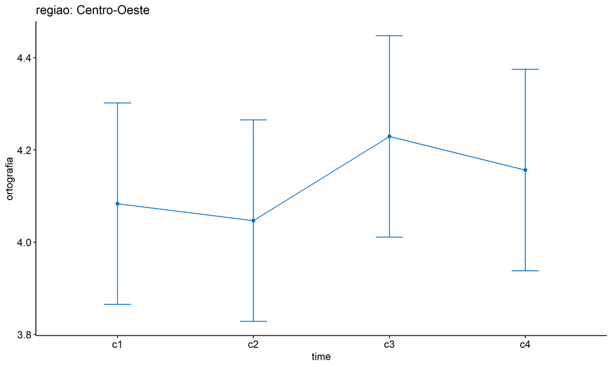

```r
emms.gg <- emms[which(emms$regiao == "Centro-Oeste"),]
if (nrow(emms.gg) > 0)
  ggline(emms.gg, x = "time", y = "emmean", color = "#0073C2FF", ylab = "ortografia") +
    geom_errorbar(aes(ymin = conf.low, ymax = conf.high),
                  width = 0.2, color = "#0073C2FF") +
    stat_pvalue_manual(
      add_xy_position(pwc[which(pwc$regiao == "Centro-Oeste"),],
                      x = "time", fun = "mean_se"),
      hide.ns = T, color = "#0073C2FF", tip.length = F) +
    labs(title = "regiao: Centro-Oeste")+
    theme(legend.text = element_blank())
```

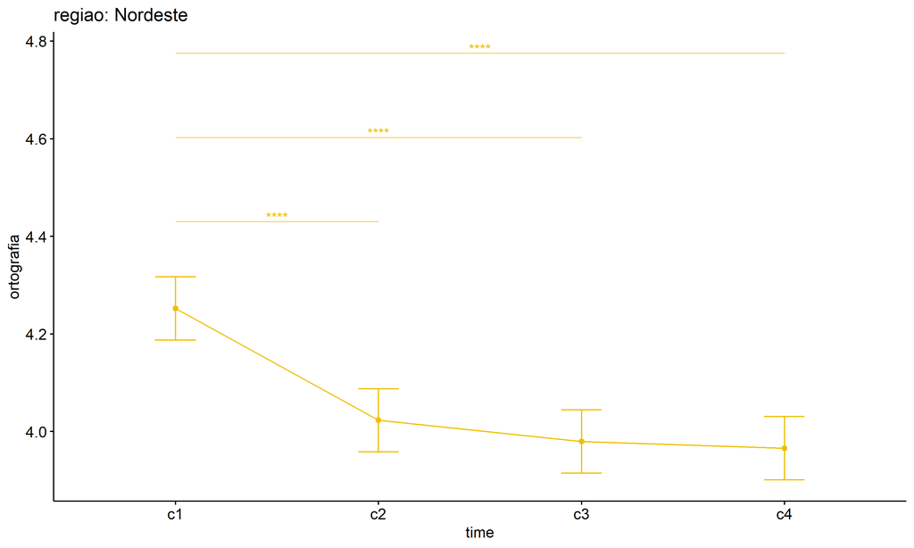

```r
emms.gg <- emms[which(emms$regiao == "Nordeste"),]
if (nrow(emms.gg) > 0)
  ggline(emms.gg, x = "time", y = "emmean", color = "#EFC000FF", ylab = "ortografia") +
    geom_errorbar(aes(ymin = conf.low, ymax = conf.high),
                  width = 0.2, color = "#EFC000FF") +
    stat_pvalue_manual(
      add_xy_position(pwc[which(pwc$regiao == "Nordeste"),],
                      x = "time", fun = "mean_se"),
      hide.ns = T, color = "#EFC000FF", tip.length = F) +
    labs(title = "regiao: Nordeste")+
    theme(legend.text = element_blank())
```

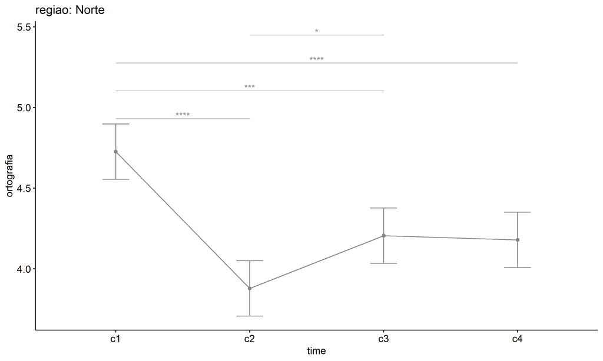

```r
emms.gg <- emms[which(emms$regiao == "Norte"),]
if (nrow(emms.gg) > 0)
  ggline(emms.gg, x = "time", y = "emmean", color = "#868686FF", ylab = "ortografia") +
    geom_errorbar(aes(ymin = conf.low, ymax = conf.high),
                  width = 0.2, color = "#868686FF") +
    stat_pvalue_manual(
      add_xy_position(pwc[which(pwc$regiao == "Norte"),],
                      x = "time", fun = "mean_se"),
      hide.ns = T, color = "#868686FF", tip.length = F) +
    labs(title = "regiao: Norte")+
    theme(legend.text = element_blank())
```

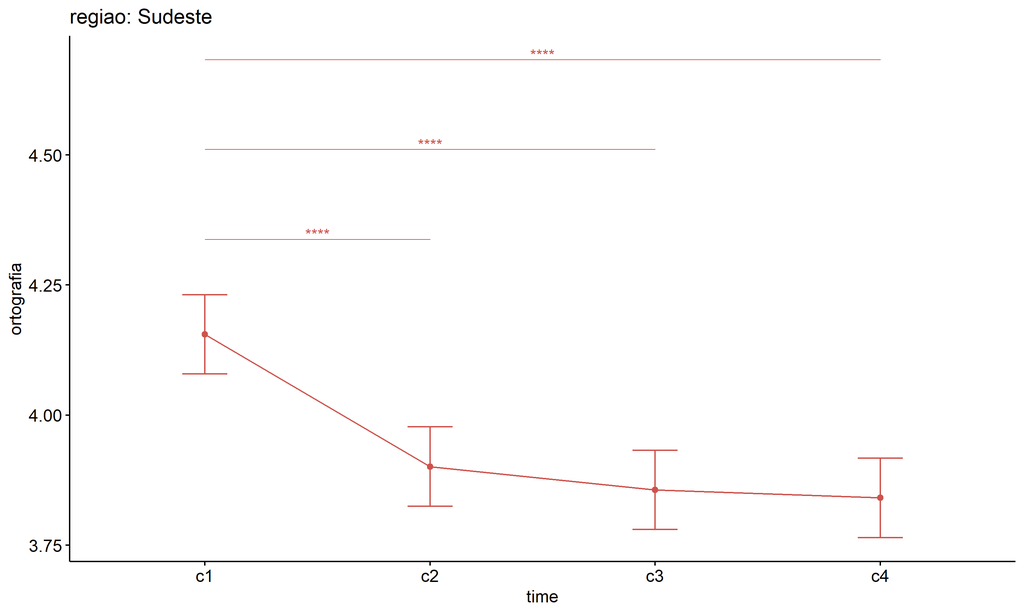

```r
emms.gg <- emms[which(emms$regiao == "Sudeste"),]
if (nrow(emms.gg) > 0)
  ggline(emms.gg, x = "time", y = "emmean", color = "#CD534CFF", ylab = "ortografia") +
    geom_errorbar(aes(ymin = conf.low, ymax = conf.high),
                  width = 0.2, color = "#CD534CFF") +
    stat_pvalue_manual(
      add_xy_position(pwc[which(pwc$regiao == "Sudeste"),],
                      x = "time", fun = "mean_se"),
      hide.ns = T, color = "#CD534CFF", tip.length = F) +
    labs(title = "regiao: Sudeste")+
    theme(legend.text = element_blank())
```

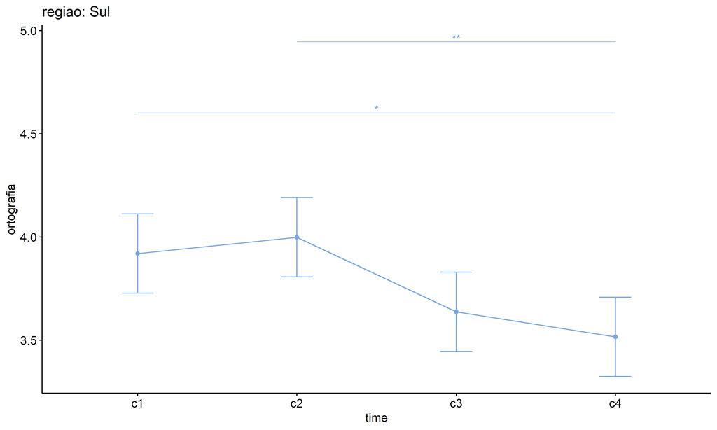

```r
emms.gg <- emms[which(emms$regiao == "Sul"),]
if (nrow(emms.gg) > 0)
  ggline(emms.gg, x = "time", y = "emmean", color = "#7AA6DCFF", ylab = "ortografia") +
    geom_errorbar(aes(ymin = conf.low, ymax = conf.high),
                  width = 0.2, color = "#7AA6DCFF") +
    stat_pvalue_manual(
      add_xy_position(pwc[which(pwc$regiao == "Sul"),],
                      x = "time", fun = "mean_se"),
      hide.ns = T, color = "#7AA6DCFF", tip.length = F) +
    labs(title = "regiao: Sul")+
    theme(legend.text = element_blank())
```

## PairWise Computation after removing non.normal data

```r
if (length(non.ids) > 0)
  (pwc2 <- ldat2 %>% group_by(time) %>%
     emmeans_test(ortografia ~ regiao, detailed = T, p.adjust.method = "bonferroni"))
```

| time | term | .y. | group1 | group2 | null.value | estimate | se | df | conf.low | conf.high | statistic | p | p.adj | p.adj.signif |
| --- | --- | --- | --- | --- | --- | --- | --- | --- | --- | --- | --- | --- | --- | --- |
| c1 | regiao | ortografia | Centro | Oeste | 0 | 0.248 | 0.775 | 3832 | -1.273 | 1.768 | 0.319 | 0.749 | 1.000 | ns |
| c1 | regiao | ortografia | Centro | Oeste | 0 | -0.342 | 0.795 | 3832 | -1.901 | 1.216 | -0.430 | 0.667 | 1.000 | ns |
| c1 | regiao | ortografia | Centro | Oeste | 0 | 0.345 | 0.776 | 3832 | -1.176 | 1.866 | 0.444 | 0.657 | 1.000 | ns |
| c1 | regiao | ortografia | Centro | Oeste | 0 | 0.100 | 0.849 | 3832 | -1.564 | 1.764 | 0.118 | 0.906 | 1.000 | ns |
| c1 | regiao | ortografia | Nordeste | Norte | 0 | -0.590 | 0.181 | 3832 | -0.944 | -0.235 | -3.262 | 0.001 | 0.011 | * |
| c1 | regiao | ortografia | Nordeste | Sudeste | 0 | 0.097 | 0.051 | 3832 | -0.003 | 0.198 | 1.893 | 0.058 | 0.584 | ns |
| c1 | regiao | ortografia | Nordeste | Sul | 0 | -0.148 | 0.348 | 3832 | -0.830 | 0.535 | -0.424 | 0.671 | 1.000 | ns |
| c1 | regiao | ortografia | Norte | Sudeste | 0 | 0.687 | 0.182 | 3832 | 0.330 | 1.044 | 3.774 | 0.000 | 0.002 | ** |
| c1 | regiao | ortografia | Norte | Sul | 0 | 0.442 | 0.389 | 3832 | -0.321 | 1.206 | 1.135 | 0.256 | 1.000 | ns |
| c1 | regiao | ortografia | Sudeste | Sul | 0 | -0.245 | 0.349 | 3832 | -0.928 | 0.439 | -0.702 | 0.483 | 1.000 | ns |
| c2 | regiao | ortografia | Centro | Oeste | 0 | 0.477 | 0.775 | 3832 | -1.043 | 1.997 | 0.615 | 0.539 | 1.000 | ns |
| c2 | regiao | ortografia | Centro | Oeste | 0 | 0.447 | 0.795 | 3832 | -1.111 | 2.006 | 0.563 | 0.574 | 1.000 | ns |
| c2 | regiao | ortografia | Centro | Oeste | 0 | 0.599 | 0.776 | 3832 | -0.922 | 2.120 | 0.772 | 0.440 | 1.000 | ns |
| c2 | regiao | ortografia | Centro | Oeste | 0 | 0.367 | 0.849 | 3832 | -1.297 | 2.031 | 0.432 | 0.666 | 1.000 | ns |
| c2 | regiao | ortografia | Nordeste | Norte | 0 | -0.030 | 0.181 | 3832 | -0.384 | 0.325 | -0.163 | 0.870 | 1.000 | ns |
| c2 | regiao | ortografia | Nordeste | Sudeste | 0 | 0.122 | 0.051 | 3832 | 0.022 | 0.223 | 2.382 | 0.017 | 0.173 | ns |
| c2 | regiao | ortografia | Nordeste | Sul | 0 | -0.110 | 0.348 | 3832 | -0.793 | 0.572 | -0.317 | 0.751 | 1.000 | ns |
| c2 | regiao | ortografia | Norte | Sudeste | 0 | 0.152 | 0.182 | 3832 | -0.205 | 0.508 | 0.833 | 0.405 | 1.000 | ns |
| c2 | regiao | ortografia | Norte | Sul | 0 | -0.081 | 0.389 | 3832 | -0.844 | 0.683 | -0.207 | 0.836 | 1.000 | ns |
| c2 | regiao | ortografia | Sudeste | Sul | 0 | -0.232 | 0.349 | 3832 | -0.916 | 0.451 | -0.666 | 0.505 | 1.000 | ns |
| c3 | regiao | ortografia | Centro | Oeste | 0 | -0.480 | 0.775 | 3832 | -2.000 | 1.041 | -0.619 | 0.536 | 1.000 | ns |
| c3 | regiao | ortografia | Centro | Oeste | 0 | -0.553 | 0.795 | 3832 | -2.111 | 1.006 | -0.695 | 0.487 | 1.000 | ns |
| c3 | regiao | ortografia | Centro | Oeste | 0 | -0.356 | 0.776 | 3832 | -1.877 | 1.165 | -0.459 | 0.646 | 1.000 | ns |
| c3 | regiao | ortografia | Centro | Oeste | 0 | -0.700 | 0.849 | 3832 | -2.364 | 0.964 | -0.825 | 0.410 | 1.000 | ns |
| c3 | regiao | ortografia | Nordeste | Norte | 0 | -0.073 | 0.181 | 3832 | -0.427 | 0.282 | -0.403 | 0.687 | 1.000 | ns |
| c3 | regiao | ortografia | Nordeste | Sudeste | 0 | 0.124 | 0.051 | 3832 | 0.023 | 0.224 | 2.410 | 0.016 | 0.160 | ns |
| c3 | regiao | ortografia | Nordeste | Sul | 0 | -0.220 | 0.348 | 3832 | -0.903 | 0.462 | -0.633 | 0.527 | 1.000 | ns |
| c3 | regiao | ortografia | Norte | Sudeste | 0 | 0.196 | 0.182 | 3832 | -0.160 | 0.553 | 1.079 | 0.281 | 1.000 | ns |
| c3 | regiao | ortografia | Norte | Sul | 0 | -0.147 | 0.389 | 3832 | -0.911 | 0.616 | -0.378 | 0.705 | 1.000 | ns |
| c3 | regiao | ortografia | Sudeste | Sul | 0 | -0.344 | 0.349 | 3832 | -1.027 | 0.340 | -0.986 | 0.324 | 1.000 | ns |
| c4 | regiao | ortografia | Centro | Oeste | 0 | 0.534 | 0.775 | 3832 | -0.986 | 2.054 | 0.689 | 0.491 | 1.000 | ns |
| c4 | regiao | ortografia | Centro | Oeste | 0 | 0.289 | 0.795 | 3832 | -1.269 | 1.848 | 0.364 | 0.716 | 1.000 | ns |
| c4 | regiao | ortografia | Centro | Oeste | 0 | 0.659 | 0.776 | 3832 | -0.862 | 2.180 | 0.850 | 0.396 | 1.000 | ns |
| c4 | regiao | ortografia | Centro | Oeste | 0 | 0.500 | 0.849 | 3832 | -1.164 | 2.164 | 0.589 | 0.556 | 1.000 | ns |
| c4 | regiao | ortografia | Nordeste | Norte | 0 | -0.244 | 0.181 | 3832 | -0.599 | 0.110 | -1.352 | 0.176 | 1.000 | ns |
| c4 | regiao | ortografia | Nordeste | Sudeste | 0 | 0.125 | 0.051 | 3832 | 0.025 | 0.226 | 2.440 | 0.015 | 0.147 | ns |
| c4 | regiao | ortografia | Nordeste | Sul | 0 | -0.034 | 0.348 | 3832 | -0.716 | 0.648 | -0.098 | 0.922 | 1.000 | ns |
| c4 | regiao | ortografia | Norte | Sudeste | 0 | 0.370 | 0.182 | 3832 | 0.013 | 0.726 | 2.031 | 0.042 | 0.424 | ns |
| c4 | regiao | ortografia | Norte | Sul | 0 | 0.211 | 0.389 | 3832 | -0.553 | 0.974 | 0.541 | 0.589 | 1.000 | ns |
| c4 | regiao | ortografia | Sudeste | Sul | 0 | -0.159 | 0.349 | 3832 | -0.843 | 0.525 | -0.456 | 0.648 | 1.000 | ns |

```r
if (length(non.ids) > 0)
  (emms2 <- get_emmeans(pwc2))
```

```
## # A tibble: 20 × 8
##    time  regiao       emmean     se    df conf.low conf.high method
##    <fct> <fct>         <dbl>  <dbl> <dbl>    <dbl>     <dbl> <chr>
##  1 c1    Centro-Oeste   4.50 0.775   3832     2.98      6.02 Emmeans test
##  2 c1    Nordeste       4.25 0.0332  3832     4.19      4.32 Emmeans test
##  3 c1    Norte          4.84 0.178   3832     4.49      5.19 Emmeans test
##  4 c1    Sudeste        4.16 0.0391  3832     4.08      4.23 Emmeans test
##  5 c1    Sul            4.40 0.346   3832     3.72      5.08 Emmeans test
##  6 c2    Centro-Oeste   4.50 0.775   3832     2.98      6.02 Emmeans test
##  7 c2    Nordeste       4.02 0.0332  3832     3.96      4.09 Emmeans test
##  8 c2    Norte          4.05 0.178   3832     3.70      4.40 Emmeans test
##  9 c2    Sudeste        3.90 0.0391  3832     3.82      3.98 Emmeans test
## 10 c2    Sul            4.13 0.346   3832     3.45      4.81 Emmeans test
## 11 c3    Centro-Oeste   3.50 0.775   3832     1.98      5.02 Emmeans test
## 12 c3    Nordeste       3.98 0.0332  3832     3.91      4.04 Emmeans test
## 13 c3    Norte          4.05 0.178   3832     3.70      4.40 Emmeans test
## 14 c3    Sudeste        3.86 0.0391  3832     3.78      3.93 Emmeans test
## 15 c3    Sul            4.20 0.346   3832     3.52      4.88 Emmeans test
## 16 c4    Centro-Oeste   4.50 0.775   3832     2.98      6.02 Emmeans test
## 17 c4    Nordeste       3.97 0.0332  3832     3.90      4.03 Emmeans test
## 18 c4    Norte          4.21 0.178   3832     3.86      4.56 Emmeans test
## 19 c4    Sudeste        3.84 0.0391  3832     3.76      3.92 Emmeans test
## 20 c4    Sul            4.00 0.346   3832     3.32      4.68 Emmeans test
```

| time | regiao | emmean | se | df | conf.low | conf.high | method |
| --- | --- | --- | --- | --- | --- | --- | --- |
| c1 | Centro-Oeste | 4.500 | 0.775 | 3832 | 2.981 | 6.019 | Emmeans test |
| c1 | Nordeste | 4.252 | 0.033 | 3832 | 4.187 | 4.317 | Emmeans test |
| c1 | Norte | 4.842 | 0.178 | 3832 | 4.494 | 5.191 | Emmeans test |
| c1 | Sudeste | 4.155 | 0.039 | 3832 | 4.079 | 4.232 | Emmeans test |
| c1 | Sul | 4.400 | 0.346 | 3832 | 3.721 | 5.079 | Emmeans test |
| c2 | Centro-Oeste | 4.500 | 0.775 | 3832 | 2.981 | 6.019 | Emmeans test |
| c2 | Nordeste | 4.023 | 0.033 | 3832 | 3.958 | 4.088 | Emmeans test |
| c2 | Norte | 4.053 | 0.178 | 3832 | 3.704 | 4.401 | Emmeans test |
| c2 | Sudeste | 3.901 | 0.039 | 3832 | 3.824 | 3.978 | Emmeans test |
| c2 | Sul | 4.133 | 0.346 | 3832 | 3.454 | 4.813 | Emmeans test |
| c3 | Centro-Oeste | 3.500 | 0.775 | 3832 | 1.981 | 5.019 | Emmeans test |
| c3 | Nordeste | 3.980 | 0.033 | 3832 | 3.915 | 4.045 | Emmeans test |
| c3 | Norte | 4.053 | 0.178 | 3832 | 3.704 | 4.401 | Emmeans test |
| c3 | Sudeste | 3.856 | 0.039 | 3832 | 3.780 | 3.933 | Emmeans test |
| c3 | Sul | 4.200 | 0.346 | 3832 | 3.521 | 4.879 | Emmeans test |
| c4 | Centro-Oeste | 4.500 | 0.775 | 3832 | 2.981 | 6.019 | Emmeans test |
| c4 | Nordeste | 3.966 | 0.033 | 3832 | 3.901 | 4.031 | Emmeans test |
| c4 | Norte | 4.211 | 0.178 | 3832 | 3.862 | 4.559 | Emmeans test |
| c4 | Sudeste | 3.841 | 0.039 | 3832 | 3.764 | 3.918 | Emmeans test |
| c4 | Sul | 4.000 | 0.346 | 3832 | 3.321 | 4.679 | Emmeans test |

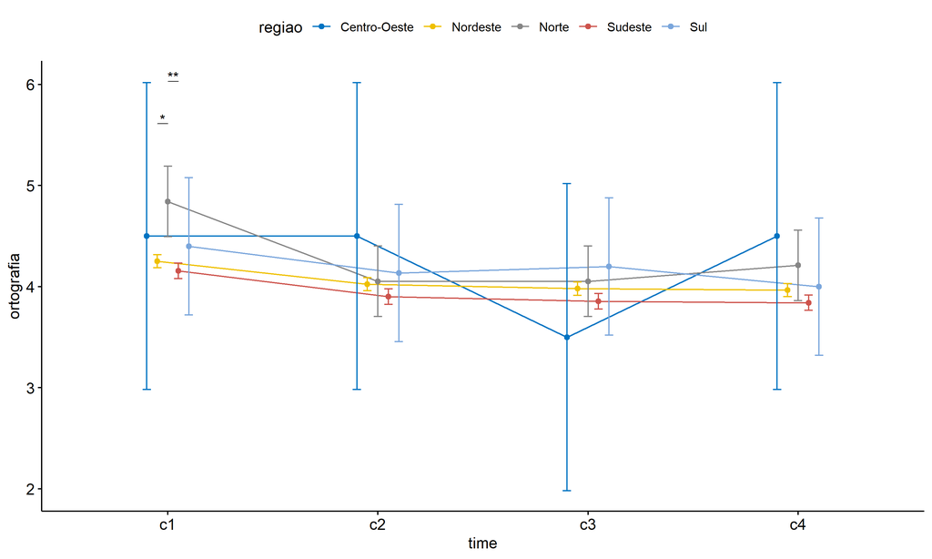

```r
if (length(non.ids) > 0) {
  pwc2 <- add_xy_position(pwc2, x = "time", fun = "mean_se", dodge = 0.25)
  pd2 <- position_dodge(width = 0.25)

  ggline(emms2, x = "time", y = "emmean", color = "regiao",
         palette = c("#0073C2FF","#EFC000FF","#868686FF","#CD534CFF","#7AA6DCFF"),
         position = pd, ylab = "ortografia") +
    geom_errorbar(aes(ymin = conf.low, ymax = conf.high, color = regiao),
                position = pd, width = 0.2) +
    stat_pvalue_manual(pwc2, hide.ns = T, tip.length = F, linetype = 1)
}
```

```r
if (length(non.ids) > 0)
  (pwc2 <- ldat2 %>% group_by(regiao) %>%
     emmeans_test(ortografia ~ time, detailed = T, p.adjust.method = "bonferroni"))
```

```
## # A tibble: 30 × 15
##    regiao   term  .y.   group1 group2 null.value  estimate     se    df conf.low
##  * <fct>    <chr> <chr> <chr>  <chr>       <dbl>     <dbl>  <dbl> <dbl>    <dbl>
##  1 Centro-… time  orto… c1     c2              0  4.55e-12 1.10    3832  -2.15
##  2 Centro-… time  orto… c1     c3              0  1.00e+ 0 1.10    3832  -1.15
##  3 Centro-… time  orto… c1     c4              0  4.67e-12 1.10    3832  -2.15
##  4 Centro-… time  orto… c2     c3              0  1.00e+ 0 1.10    3832  -1.15
##  5 Centro-… time  orto… c2     c4              0  1.22e-13 1.10    3832  -2.15
##  6 Centro-… time  orto… c3     c4              0 -1.00e+ 0 1.10    3832  -3.15
##  7 Nordeste time  orto… c1     c2              0  2.29e- 1 0.0469  3832   0.137
##  8 Nordeste time  orto… c1     c3              0  2.72e- 1 0.0469  3832   0.180
##  9 Nordeste time  orto… c1     c4              0  2.86e- 1 0.0469  3832   0.194
## 10 Nordeste time  orto… c2     c3              0  4.33e- 2 0.0469  3832  -0.0487
## # ℹ 20 more rows
## # ℹ 5 more variables: conf.high <dbl>, statistic <dbl>, p <dbl>, p.adj <dbl>,
## #   p.adj.signif <chr>
```

| regiao | term | .y. | group1 | group2 | null.value | estimate | se | df | conf.low | conf.high | statistic | p | p.adj | p.adj.signif |
| --- | --- | --- | --- | --- | --- | --- | --- | --- | --- | --- | --- | --- | --- | --- |
| Centro-Oeste | time | ortografia | c1 | c2 | 0 | 0.000 | 1.096 | 3832 | -2.148 | 2.148 | 0.000 | 1.000 | 1.000 | ns |
| Centro-Oeste | time | ortografia | c1 | c3 | 0 | 1.000 | 1.096 | 3832 | -1.148 | 3.148 | 0.913 | 0.361 | 1.000 | ns |
| Centro-Oeste | time | ortografia | c1 | c4 | 0 | 0.000 | 1.096 | 3832 | -2.148 | 2.148 | 0.000 | 1.000 | 1.000 | ns |
| Centro-Oeste | time | ortografia | c2 | c3 | 0 | 1.000 | 1.096 | 3832 | -1.148 | 3.148 | 0.913 | 0.361 | 1.000 | ns |
| Centro-Oeste | time | ortografia | c2 | c4 | 0 | 0.000 | 1.096 | 3832 | -2.148 | 2.148 | 0.000 | 1.000 | 1.000 | ns |
| Centro-Oeste | time | ortografia | c3 | c4 | 0 | -1.000 | 1.096 | 3832 | -3.148 | 1.148 | -0.913 | 0.361 | 1.000 | ns |
| Nordeste | time | ortografia | c1 | c2 | 0 | 0.229 | 0.047 | 3832 | 0.137 | 0.321 | 4.884 | 0.000 | 0.000 | **** |
| Nordeste | time | ortografia | c1 | c3 | 0 | 0.272 | 0.047 | 3832 | 0.180 | 0.364 | 5.806 | 0.000 | 0.000 | **** |
| Nordeste | time | ortografia | c1 | c4 | 0 | 0.286 | 0.047 | 3832 | 0.194 | 0.378 | 6.099 | 0.000 | 0.000 | **** |
| Nordeste | time | ortografia | c2 | c3 | 0 | 0.043 | 0.047 | 3832 | -0.049 | 0.135 | 0.922 | 0.357 | 1.000 | ns |
| Nordeste | time | ortografia | c2 | c4 | 0 | 0.057 | 0.047 | 3832 | -0.035 | 0.149 | 1.215 | 0.224 | 1.000 | ns |
| Nordeste | time | ortografia | c3 | c4 | 0 | 0.014 | 0.047 | 3832 | -0.078 | 0.106 | 0.293 | 0.769 | 1.000 | ns |
| Norte | time | ortografia | c1 | c2 | 0 | 0.789 | 0.251 | 3832 | 0.297 | 1.282 | 3.141 | 0.002 | 0.010 | * |
| Norte | time | ortografia | c1 | c3 | 0 | 0.789 | 0.251 | 3832 | 0.297 | 1.282 | 3.141 | 0.002 | 0.010 | * |
| Norte | time | ortografia | c1 | c4 | 0 | 0.632 | 0.251 | 3832 | 0.139 | 1.124 | 2.513 | 0.012 | 0.072 | ns |
| Norte | time | ortografia | c2 | c3 | 0 | 0.000 | 0.251 | 3832 | -0.493 | 0.493 | 0.000 | 1.000 | 1.000 | ns |
| Norte | time | ortografia | c2 | c4 | 0 | -0.158 | 0.251 | 3832 | -0.651 | 0.335 | -0.628 | 0.530 | 1.000 | ns |
| Norte | time | ortografia | c3 | c4 | 0 | -0.158 | 0.251 | 3832 | -0.651 | 0.335 | -0.628 | 0.530 | 1.000 | ns |
| Sudeste | time | ortografia | c1 | c2 | 0 | 0.254 | 0.055 | 3832 | 0.146 | 0.363 | 4.600 | 0.000 | 0.000 | **** |
| Sudeste | time | ortografia | c1 | c3 | 0 | 0.299 | 0.055 | 3832 | 0.191 | 0.407 | 5.410 | 0.000 | 0.000 | **** |
| Sudeste | time | ortografia | c1 | c4 | 0 | 0.314 | 0.055 | 3832 | 0.206 | 0.423 | 5.686 | 0.000 | 0.000 | **** |
| Sudeste | time | ortografia | c2 | c3 | 0 | 0.045 | 0.055 | 3832 | -0.064 | 0.153 | 0.810 | 0.418 | 1.000 | ns |
| Sudeste | time | ortografia | c2 | c4 | 0 | 0.060 | 0.055 | 3832 | -0.048 | 0.168 | 1.086 | 0.278 | 1.000 | ns |
| Sudeste | time | ortografia | c3 | c4 | 0 | 0.015 | 0.055 | 3832 | -0.093 | 0.124 | 0.276 | 0.782 | 1.000 | ns |
| Sul | time | ortografia | c1 | c2 | 0 | 0.267 | 0.490 | 3832 | -0.694 | 1.227 | 0.544 | 0.586 | 1.000 | ns |
| Sul | time | ortografia | c1 | c3 | 0 | 0.200 | 0.490 | 3832 | -0.761 | 1.161 | 0.408 | 0.683 | 1.000 | ns |
| Sul | time | ortografia | c1 | c4 | 0 | 0.400 | 0.490 | 3832 | -0.561 | 1.361 | 0.816 | 0.414 | 1.000 | ns |
| Sul | time | ortografia | c2 | c3 | 0 | -0.067 | 0.490 | 3832 | -1.027 | 0.894 | -0.136 | 0.892 | 1.000 | ns |
| Sul | time | ortografia | c2 | c4 | 0 | 0.133 | 0.490 | 3832 | -0.827 | 1.094 | 0.272 | 0.786 | 1.000 | ns |
| Sul | time | ortografia | c3 | c4 | 0 | 0.200 | 0.490 | 3832 | -0.761 | 1.161 | 0.408 | 0.683 | 1.000 | ns |

```r
if (length(non.ids) > 0)
  (emms2 <- get_emmeans(pwc2))
```

```
## # A tibble: 20 × 8
##    regiao       time  emmean     se    df conf.low conf.high method
##    <fct>        <fct>  <dbl>  <dbl> <dbl>    <dbl>     <dbl> <chr>
##  1 Centro-Oeste c1      4.50 0.775   3832     2.98      6.02 Emmeans test
##  2 Centro-Oeste c2      4.50 0.775   3832     2.98      6.02 Emmeans test
##  3 Centro-Oeste c3      3.50 0.775   3832     1.98      5.02 Emmeans test
##  4 Centro-Oeste c4      4.50 0.775   3832     2.98      6.02 Emmeans test
##  5 Nordeste     c1      4.25 0.0332  3832     4.19      4.32 Emmeans test
##  6 Nordeste     c2      4.02 0.0332  3832     3.96      4.09 Emmeans test
##  7 Nordeste     c3      3.98 0.0332  3832     3.91      4.04 Emmeans test
##  8 Nordeste     c4      3.97 0.0332  3832     3.90      4.03 Emmeans test
##  9 Norte        c1      4.84 0.178   3832     4.49      5.19 Emmeans test
## 10 Norte        c2      4.05 0.178   3832     3.70      4.40 Emmeans test
## 11 Norte        c3      4.05 0.178   3832     3.70      4.40 Emmeans test
## 12 Norte        c4      4.21 0.178   3832     3.86      4.56 Emmeans test
## 13 Sudeste      c1      4.16 0.0391  3832     4.08      4.23 Emmeans test
## 14 Sudeste      c2      3.90 0.0391  3832     3.82      3.98 Emmeans test
## 15 Sudeste      c3      3.86 0.0391  3832     3.78      3.93 Emmeans test
## 16 Sudeste      c4      3.84 0.0391  3832     3.76      3.92 Emmeans test
## 17 Sul          c1      4.40 0.346   3832     3.72      5.08 Emmeans test
## 18 Sul          c2      4.13 0.346   3832     3.45      4.81 Emmeans test
## 19 Sul          c3      4.20 0.346   3832     3.52      4.88 Emmeans test
## 20 Sul          c4      4.00 0.346   3832     3.32      4.68 Emmeans test
```

| regiao | time | emmean | se | df | conf.low | conf.high | method |
| --- | --- | --- | --- | --- | --- | --- | --- |
| Centro-Oeste | c1 | 4.500 | 0.775 | 3832 | 2.981 | 6.019 | Emmeans test |
| Centro-Oeste | c2 | 4.500 | 0.775 | 3832 | 2.981 | 6.019 | Emmeans test |
| Centro-Oeste | c3 | 3.500 | 0.775 | 3832 | 1.981 | 5.019 | Emmeans test |
| Centro-Oeste | c4 | 4.500 | 0.775 | 3832 | 2.981 | 6.019 | Emmeans test |
| Nordeste | c1 | 4.252 | 0.033 | 3832 | 4.187 | 4.317 | Emmeans test |
| Nordeste | c2 | 4.023 | 0.033 | 3832 | 3.958 | 4.088 | Emmeans test |
| Nordeste | c3 | 3.980 | 0.033 | 3832 | 3.915 | 4.045 | Emmeans test |
| Nordeste | c4 | 3.966 | 0.033 | 3832 | 3.901 | 4.031 | Emmeans test |
| Norte | c1 | 4.842 | 0.178 | 3832 | 4.494 | 5.191 | Emmeans test |
| Norte | c2 | 4.053 | 0.178 | 3832 | 3.704 | 4.401 | Emmeans test |
| Norte | c3 | 4.053 | 0.178 | 3832 | 3.704 | 4.401 | Emmeans test |
| Norte | c4 | 4.211 | 0.178 | 3832 | 3.862 | 4.559 | Emmeans test |
| Sudeste | c1 | 4.155 | 0.039 | 3832 | 4.079 | 4.232 | Emmeans test |
| Sudeste | c2 | 3.901 | 0.039 | 3832 | 3.824 | 3.978 | Emmeans test |
| Sudeste | c3 | 3.856 | 0.039 | 3832 | 3.780 | 3.933 | Emmeans test |
| Sudeste | c4 | 3.841 | 0.039 | 3832 | 3.764 | 3.918 | Emmeans test |
| Sul | c1 | 4.400 | 0.346 | 3832 | 3.721 | 5.079 | Emmeans test |
| Sul | c2 | 4.133 | 0.346 | 3832 | 3.454 | 4.813 | Emmeans test |
| Sul | c3 | 4.200 | 0.346 | 3832 | 3.521 | 4.879 | Emmeans test |
| Sul | c4 | 4.000 | 0.346 | 3832 | 3.321 | 4.679 | Emmeans test |

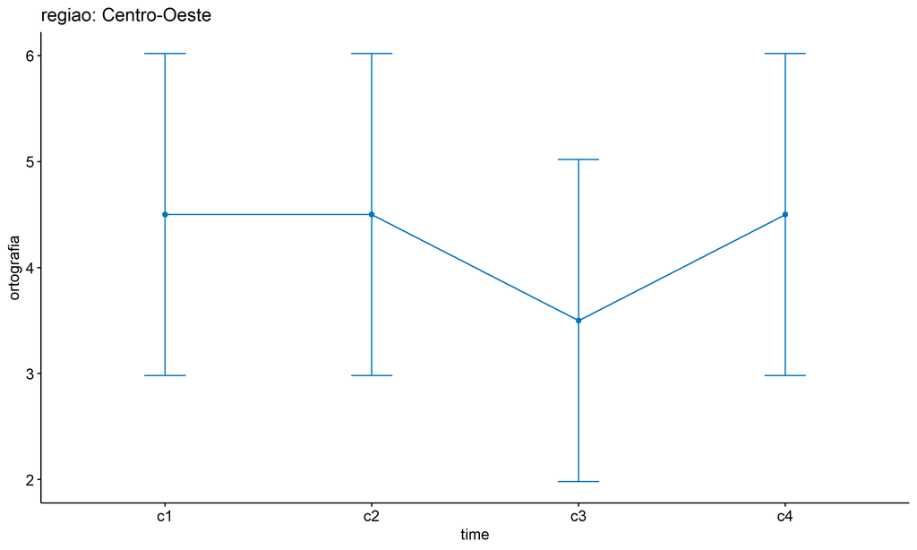

```r
if (length(non.ids) > 0) {
  emms.gg <- emms2[which(emms2$regiao == "Centro-Oeste"),]
  if (nrow(emms.gg) > 0)
    ggline(emms.gg, x = "time", y = "emmean", color = "#0073C2FF", ylab = "ortografia") +
    geom_errorbar(aes(ymin = conf.low, ymax = conf.high),
                  width = 0.2, color = "#0073C2FF") +
    stat_pvalue_manual(
      add_xy_position(pwc[which(pwc$regiao == "Centro-Oeste"),],
                      x = "time", fun = "mean_se"),
      hide.ns = T, color = "#0073C2FF", tip.length = F) +
    labs(title = "regiao: Centro-Oeste") +
    theme(legend.text = element_blank())
}
```

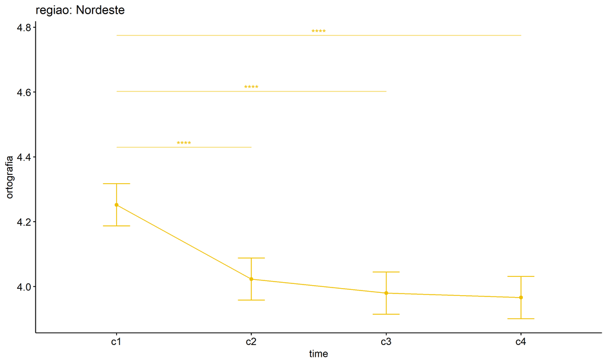

```r
if (length(non.ids) > 0) {
  emms.gg <- emms2[which(emms2$regiao == "Nordeste"),]
  if (nrow(emms.gg) > 0)
    ggline(emms.gg, x = "time", y = "emmean", color = "#EFC000FF", ylab = "ortografia") +
    geom_errorbar(aes(ymin = conf.low, ymax = conf.high),
                  width = 0.2, color = "#EFC000FF") +
    stat_pvalue_manual(
      add_xy_position(pwc[which(pwc$regiao == "Nordeste"),],
                      x = "time", fun = "mean_se"),
      hide.ns = T, color = "#EFC000FF", tip.length = F) +
    labs(title = "regiao: Nordeste") +
    theme(legend.text = element_blank())
}
```

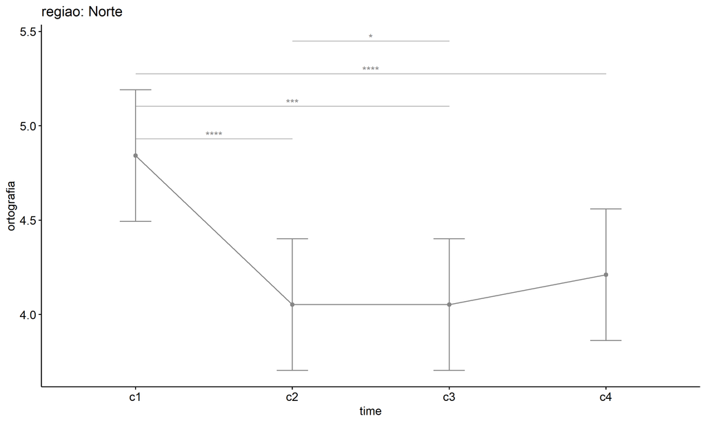

```r
if (length(non.ids) > 0) {
  emms.gg <- emms2[which(emms2$regiao == "Norte"),]
  if (nrow(emms.gg) > 0)
    ggline(emms.gg, x = "time", y = "emmean", color = "#868686FF", ylab = "ortografia") +
    geom_errorbar(aes(ymin = conf.low, ymax = conf.high),
                  width = 0.2, color = "#868686FF") +
    stat_pvalue_manual(
      add_xy_position(pwc[which(pwc$regiao == "Norte"),],
                      x = "time", fun = "mean_se"),
      hide.ns = T, color = "#868686FF", tip.length = F) +
    labs(title = "regiao: Norte") +
    theme(legend.text = element_blank())
}
```

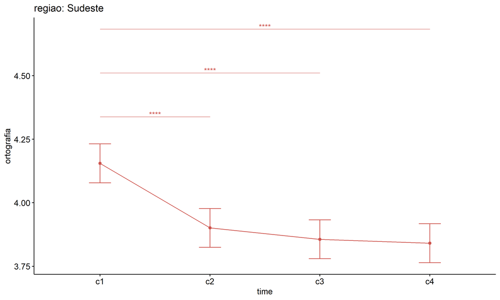

```r
if (length(non.ids) > 0) {
  emms.gg <- emms2[which(emms2$regiao == "Sudeste"),]
  if (nrow(emms.gg) > 0)
    ggline(emms.gg, x = "time", y = "emmean", color = "#CD534CFF", ylab = "ortografia") +
    geom_errorbar(aes(ymin = conf.low, ymax = conf.high),
                  width = 0.2, color = "#CD534CFF") +
    stat_pvalue_manual(
      add_xy_position(pwc[which(pwc$regiao == "Sudeste"),],
                      x = "time", fun = "mean_se"),
      hide.ns = T, color = "#CD534CFF", tip.length = F) +
    labs(title = "regiao: Sudeste") +
    theme(legend.text = element_blank())
}
```

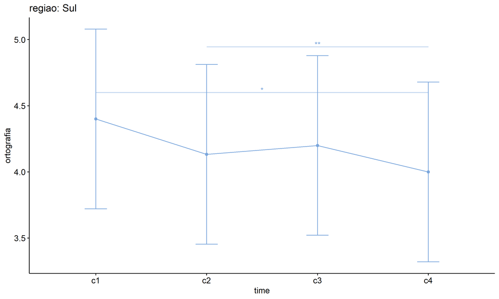

```r
if (length(non.ids) > 0) {
  emms.gg <- emms2[which(emms2$regiao == "Sul"),]
  if (nrow(emms.gg) > 0)
    ggline(emms.gg, x = "time", y = "emmean", color = "#7AA6DCFF", ylab = "ortografia") +
    geom_errorbar(aes(ymin = conf.low, ymax = conf.high),
                  width = 0.2, color = "#7AA6DCFF") +
    stat_pvalue_manual(
      add_xy_position(pwc[which(pwc$regiao == "Sul"),],
                      x = "time", fun = "mean_se"),
      hide.ns = T, color = "#7AA6DCFF", tip.length = F) +
    labs(title = "regiao: Sul") +
    theme(legend.text = element_blank())
}
```

# ANOVA: ortografia ~ time*porte + Error(id/time)

## Data Preparation

```r
data <- edat[,c("aluno_id","porte","ciclo","ortografia")]
data <- data[data$ciclo %in% c("Primeiro Ciclo","Segundo Ciclo","Terceiro Ciclo","Quarto Ciclo"),]
data$ciclo <- factor(data$ciclo, c("Primeiro Ciclo","Segundo Ciclo","Terceiro Ciclo","Quarto Ciclo"))
data <- unique(data)

wdat <- spread(data, ciclo, ortografia)
wdat <- wdat[complete.cases(wdat),]
colnames(wdat) <- c("id","porte","c1","c2","c3","c4")

ldat <- gather(wdat, key = time, value = ortografia, c1,c2,c3,c4) %>%
  convert_as_factor(id, time)
ldat <- remove_group_data(ldat, "ortografia", c("time", "porte"), n.limit = 30)
ldat$porte <- factor(ldat$porte, sort(unique(ldat$porte)))
```

### Check assumptions: Identifying Outliers

```r
outliers <- identify_outliers(group_by(ldat, time, porte), ortografia)
(outliers <- outliers[outliers$is.extreme == T,])
```

```
## [1] porte      time       id         ortografia is.outlier is.extreme
## <0 rows> (or 0-length row.names)
```

| porte | time | id | ortografia | is.outlier | is.extreme |
| --- | --- | --- | --- | --- | --- |

### Check assumptions: Normality Test

```r
(normality.df <- normality.test.per.groups(ldat, "ortografia", c("time", "porte")))
```

```
##           var   variable time                                        porte   n
## 1  ortografia ortografia   c1           Até 50 matrículas de escolarização  33
## 2  ortografia ortografia   c1  Entre 201 e 500 matrículas de escolarização 675
## 3  ortografia ortografia   c1 Entre 501 e 1000 matrículas de escolarização 249
## 4  ortografia ortografia   c1   Entre 51 e 200 matrículas de escolarização 162
## 5  ortografia ortografia   c2           Até 50 matrículas de escolarização  33
## 6  ortografia ortografia   c2  Entre 201 e 500 matrículas de escolarização 675
## 7  ortografia ortografia   c2 Entre 501 e 1000 matrículas de escolarização 249
## 8  ortografia ortografia   c2   Entre 51 e 200 matrículas de escolarização 162
## 9  ortografia ortografia   c3           Até 50 matrículas de escolarização  33
## 10 ortografia ortografia   c3  Entre 201 e 500 matrículas de escolarização 675
## 11 ortografia ortografia   c3 Entre 501 e 1000 matrículas de escolarização 249
## 12 ortografia ortografia   c3   Entre 51 e 200 matrículas de escolarização 162
## 13 ortografia ortografia   c4           Até 50 matrículas de escolarização  33
## 14 ortografia ortografia   c4  Entre 201 e 500 matrículas de escolarização 675
```

[output cut: 36 more lines]

| var | variable | time | porte | n | skewness | kurtosis | symmetry | statistic | method | p | p.signif | normality |
| --- | --- | --- | --- | --- | --- | --- | --- | --- | --- | --- | --- | --- |
| ortografia | ortografia | c1 | Até 50 matrículas de escolarização | 33 | -0.294 | -0.976 | YES | 0.844 | Shapiro-Wilk | 0 | *** | NO |
| ortografia | ortografia | c1 | Entre 201 e 500 matrículas de escolarização | 675 | -0.482 | -1.253 | YES | 709.573 | D’Agostino | 0 | **** | - |
| ortografia | ortografia | c1 | Entre 501 e 1000 matrículas de escolarização | 249 | -0.465 | -1.273 | YES | 193.290 | D’Agostino | 0 | **** | - |
| ortografia | ortografia | c1 | Entre 51 e 200 matrículas de escolarização | 162 | -0.249 | -1.515 | YES | 1521.870 | D’Agostino | 0 | **** | QQ |
| ortografia | ortografia | c2 | Até 50 matrículas de escolarização | 33 | -0.042 | -1.517 | YES | 0.829 | Shapiro-Wilk | 0 | *** | NO |
| ortografia | ortografia | c2 | Entre 201 e 500 matrículas de escolarização | 675 | 0.084 | -1.361 | YES | 3949.760 | D’Agostino | 0 | **** | - |
| ortografia | ortografia | c2 | Entre 501 e 1000 matrículas de escolarização | 249 | -0.120 | -1.522 | YES | 3491.601 | D’Agostino | 0 | **** | - |
| ortografia | ortografia | c2 | Entre 51 e 200 matrículas de escolarização | 162 | 0.080 | -1.677 | YES | 1612.021 | D’Agostino | 0 | **** | QQ |
| ortografia | ortografia | c3 | Até 50 matrículas de escolarização | 33 | 0.099 | -1.492 | YES | 0.845 | Shapiro-Wilk | 0 | *** | NO |
| ortografia | ortografia | c3 | Entre 201 e 500 matrículas de escolarização | 675 | 0.043 | -1.367 | YES | 5022.165 | D’Agostino | 0 | **** | - |
| ortografia | ortografia | c3 | Entre 501 e 1000 matrículas de escolarização | 249 | 0.050 | -1.430 | YES | 1114.730 | D’Agostino | 0 | **** | - |
| ortografia | ortografia | c3 | Entre 51 e 200 matrículas de escolarização | 162 | 0.267 | -1.257 | YES | 84.886 | D’Agostino | 0 | **** | QQ |
| ortografia | ortografia | c4 | Até 50 matrículas de escolarização | 33 | 0.554 | -1.459 | NO | 0.741 | Shapiro-Wilk | 0 | **** | NO |
| ortografia | ortografia | c4 | Entre 201 e 500 matrículas de escolarização | 675 | 0.103 | -1.417 | YES | 10339.190 | D’Agostino | 0 | **** | - |
| ortografia | ortografia | c4 | Entre 501 e 1000 matrículas de escolarização | 249 | 0.215 | -1.243 | YES | 151.729 | D’Agostino | 0 | **** | - |
| ortografia | ortografia | c4 | Entre 51 e 200 matrículas de escolarização | 162 | -0.099 | -1.498 | YES | 875.901 | D’Agostino | 0 | **** | QQ |

```r
(non.ids <- unique(do.call(
  c, lapply(which(normality.df$normality == 'NO'), FUN = function(i) {
  idx = which(ldat$time == normality.df$time[i] &
                ldat$porte == normality.df$porte[i])
  getNonNormal(ldat$"ortografia"[idx], ldat$id[idx])
}))))
```

```
##  [1] "xD1wHpF1gkJCyVbkGGdU" "w7548cNc0knlzDezHzBq" "ltYX0dLBB2brT2djXB5i"
##  [4] "z2bvFgOm1tRPAL3buvNQ" "ygCWEOBsngyfEt5hGLmw" "hOmouhZRJ53dvfn3tBsJ"
##  [7] "U2EyQT1K48KPitv2x16k" "Lbwu9s0newf9Wi294FdL" "xAo0TzCEx1bIrmjqKgbj"
## [10] "VNQYsv3kH0OTOqJH3yYT" "ADdqL4oAf1WRDDiOJwkj" "vgyELVyPKZx09yEhXnEW"
## [13] "KBTZEriJAFvcWw48Xxgc" "UgYoK4SY4Mtbi2xic7Rv" "jljcKPNPjBo1MdiK1ffQ"
## [16] "L0gX2yfP95da5eDy6w4E" "8QJX5P6FygYXzjqA5njF" "iutpBZMAtM92qcbyCDHB"
## [19] "0bDRQAUpq62jJm9vcptp" "0w3VhiMf67CbcpR6aZCL" "1ZE6i0Is22PBIAZbrM0J"
## [22] "BGXXXnQoaKaHn2dkhSeE" "Rw0335zUaR2w467v8I7t" "hhm3dmBw9wzrZNM837xU"
## [25] "ewKlsdM2p1FOYevFZJEB" "4fSdH8m80yxwok1ooZYh" "7gsjMtGuUxQPUSVFnNcm"
## [28] "8qKHWcxVACuKJJSMclyf" "1D0FkPiZPusHHIh6zphq" "BFW9EcP6GxS4r3JYDkkn"
## [31] "d7fkDImOtMuiednMD3E1" "i84ihNmDZFogrHoxo3Im" "MdfO8FPiIZis82vN8Qvn"
```

```r
if (length(non.ids) > 0)
  ldat2 <- ldat[!ldat$id %in% non.ids,]
```

### Summary Statistics

```r
(sdat <- ldat %>% group_by(time, porte) %>%
   get_summary_stats(ortografia, type = "mean_sd"))
```

```
## # A tibble: 16 × 6
##    porte                                        time  variable     n  mean    sd
##    <fct>                                        <fct> <fct>    <dbl> <dbl> <dbl>
##  1 Até 50 matrículas de escolarização           c1    ortogra…    33  4.18 0.683
##  2 Entre 201 e 500 matrículas de escolarização  c1    ortogra…   675  4.24 0.781
##  3 Entre 501 e 1000 matrículas de escolarização c1    ortogra…   249  4.24 0.777
##  4 Entre 51 e 200 matrículas de escolarização   c1    ortogra…   162  4.11 0.823
##  5 Até 50 matrículas de escolarização           c2    ortogra…    33  3.97 0.79
##  6 Entre 201 e 500 matrículas de escolarização  c2    ortogra…   675  3.94 0.766
##  7 Entre 501 e 1000 matrículas de escolarização c2    ortogra…   249  4.06 0.814
##  8 Entre 51 e 200 matrículas de escolarização   c2    ortogra…   162  3.95 0.861
##  9 Até 50 matrículas de escolarização           c3    ortogra…    33  3.91 0.775
## 10 Entre 201 e 500 matrículas de escolarização  c3    ortogra…   675  3.95 0.766
## 11 Entre 501 e 1000 matrículas de escolarização c3    ortogra…   249  3.96 0.779
## 12 Entre 51 e 200 matrículas de escolarização   c3    ortogra…   162  3.86 0.749
## 13 Até 50 matrículas de escolarização           c4    ortogra…    33  3.68 0.827
## 14 Entre 201 e 500 matrículas de escolarização  c4    ortogra…   675  3.92 0.777
## 15 Entre 501 e 1000 matrículas de escolarização c4    ortogra…   249  3.88 0.739
## 16 Entre 51 e 200 matrículas de escolarização   c4    ortogra…   162  4.03 0.807
```

| porte | time | variable | n | mean | sd |
| --- | --- | --- | --- | --- | --- |
| Até 50 matrículas de escolarização | c1 | ortografia | 33 | 4.182 | 0.683 |
| Entre 201 e 500 matrículas de escolarização | c1 | ortografia | 675 | 4.243 | 0.781 |
| Entre 501 e 1000 matrículas de escolarização | c1 | ortografia | 249 | 4.244 | 0.777 |
| Entre 51 e 200 matrículas de escolarização | c1 | ortografia | 162 | 4.114 | 0.823 |
| Até 50 matrículas de escolarização | c2 | ortografia | 33 | 3.970 | 0.790 |
| Entre 201 e 500 matrículas de escolarização | c2 | ortografia | 675 | 3.937 | 0.766 |
| Entre 501 e 1000 matrículas de escolarização | c2 | ortografia | 249 | 4.058 | 0.814 |
| Entre 51 e 200 matrículas de escolarização | c2 | ortografia | 162 | 3.949 | 0.861 |
| Até 50 matrículas de escolarização | c3 | ortografia | 33 | 3.909 | 0.775 |
| Entre 201 e 500 matrículas de escolarização | c3 | ortografia | 675 | 3.952 | 0.766 |
| Entre 501 e 1000 matrículas de escolarização | c3 | ortografia | 249 | 3.962 | 0.779 |
| Entre 51 e 200 matrículas de escolarização | c3 | ortografia | 162 | 3.858 | 0.749 |
| Até 50 matrículas de escolarização | c4 | ortografia | 33 | 3.682 | 0.827 |
| Entre 201 e 500 matrículas de escolarização | c4 | ortografia | 675 | 3.922 | 0.777 |
| Entre 501 e 1000 matrículas de escolarização | c4 | ortografia | 249 | 3.878 | 0.739 |
| Entre 51 e 200 matrículas de escolarização | c4 | ortografia | 162 | 4.031 | 0.807 |

```r
if (length(non.ids) > 0)
  (sdat <- ldat2 %>% group_by(time, porte) %>%
      get_summary_stats(ortografia, type = "mean_sd"))
```

```
## # A tibble: 12 × 6
##    porte                                        time  variable     n  mean    sd
##    <fct>                                        <fct> <fct>    <dbl> <dbl> <dbl>
##  1 Entre 201 e 500 matrículas de escolarização  c1    ortogra…   675  4.24 0.781
##  2 Entre 501 e 1000 matrículas de escolarização c1    ortogra…   249  4.24 0.777
##  3 Entre 51 e 200 matrículas de escolarização   c1    ortogra…   162  4.11 0.823
##  4 Entre 201 e 500 matrículas de escolarização  c2    ortogra…   675  3.94 0.766
##  5 Entre 501 e 1000 matrículas de escolarização c2    ortogra…   249  4.06 0.814
##  6 Entre 51 e 200 matrículas de escolarização   c2    ortogra…   162  3.95 0.861
##  7 Entre 201 e 500 matrículas de escolarização  c3    ortogra…   675  3.95 0.766
##  8 Entre 501 e 1000 matrículas de escolarização c3    ortogra…   249  3.96 0.779
##  9 Entre 51 e 200 matrículas de escolarização   c3    ortogra…   162  3.86 0.749
## 10 Entre 201 e 500 matrículas de escolarização  c4    ortogra…   675  3.92 0.777
## 11 Entre 501 e 1000 matrículas de escolarização c4    ortogra…   249  3.88 0.739
## 12 Entre 51 e 200 matrículas de escolarização   c4    ortogra…   162  4.03 0.807
```

| porte | time | variable | n | mean | sd |
| --- | --- | --- | --- | --- | --- |
| Entre 201 e 500 matrículas de escolarização | c1 | ortografia | 675 | 4.243 | 0.781 |
| Entre 501 e 1000 matrículas de escolarização | c1 | ortografia | 249 | 4.244 | 0.777 |
| Entre 51 e 200 matrículas de escolarização | c1 | ortografia | 162 | 4.114 | 0.823 |
| Entre 201 e 500 matrículas de escolarização | c2 | ortografia | 675 | 3.937 | 0.766 |
| Entre 501 e 1000 matrículas de escolarização | c2 | ortografia | 249 | 4.058 | 0.814 |
| Entre 51 e 200 matrículas de escolarização | c2 | ortografia | 162 | 3.949 | 0.861 |
| Entre 201 e 500 matrículas de escolarização | c3 | ortografia | 675 | 3.952 | 0.766 |
| Entre 501 e 1000 matrículas de escolarização | c3 | ortografia | 249 | 3.962 | 0.779 |
| Entre 51 e 200 matrículas de escolarização | c3 | ortografia | 162 | 3.858 | 0.749 |
| Entre 201 e 500 matrículas de escolarização | c4 | ortografia | 675 | 3.922 | 0.777 |
| Entre 501 e 1000 matrículas de escolarização | c4 | ortografia | 249 | 3.878 | 0.739 |
| Entre 51 e 200 matrículas de escolarização | c4 | ortografia | 162 | 4.031 | 0.807 |

## ANOVA Computation

```r
(res.aov <- anova_test(ldat, dv = ortografia, wid = id, between = porte, within = time))
```

```
## ANOVA Table (type III tests)
##
## $ANOVA
##       Effect DFn  DFd      F        p p<.05      ges
## 1      porte   3 1115  0.638 5.90e-01       0.000624
## 2       time   3 3345 14.747 1.54e-09     * 0.008000
## 3 porte:time   9 3345  1.954 4.10e-02     * 0.003000
##
## $`Mauchly's Test for Sphericity`
##       Effect     W     p p<.05
## 1       time 0.988 0.017     *
## 2 porte:time 0.988 0.017     *
##
## $`Sphericity Corrections`
##       Effect   GGe        DF[GG]    p[GG] p[GG]<.05   HFe        DF[HF]
## 1       time 0.992 2.97, 3316.69 1.78e-09         * 0.994 2.98, 3326.54
## 2 porte:time 0.992 8.92, 3316.69 4.10e-02         * 0.994 8.95, 3326.54
##      p[HF] p[HF]<.05
## 1 1.69e-09         *
## 2 4.10e-02         *
```

| Effect | DFn | DFd | F | p | p<.05 | ges |
| --- | --- | --- | --- | --- | --- | --- |
| porte | 3 | 1115 | 0.638 | 0.590 |  | 0.001 |
| time | 3 | 3345 | 14.747 | 0.000 | * | 0.008 |
| porte:time | 9 | 3345 | 1.954 | 0.041 | * | 0.003 |

| Effect | W | p | p<.05 |
| --- | --- | --- | --- |
| time | 0.988 | 0.017 | * |
| porte:time | 0.988 | 0.017 | * |

| Effect | GGe | DF $$GG$$ | p $$GG$$ | p $$GG$$ <.05 | HFe | DF $$HF$$ | p $$HF$$ | p $$HF$$ <.05 |
| --- | --- | --- | --- | --- | --- | --- | --- | --- |
| time | 0.992 | 2.97, 3316.69 | 0.000 | * | 0.994 | 2.98, 3326.54 | 0.000 | * |
| porte:time | 0.992 | 8.92, 3316.69 | 0.041 | * | 0.994 | 8.95, 3326.54 | 0.041 | * |

## ANOVA Computation after removing non.normal data

```r
if (length(non.ids) > 0)
  (res.aov2 <- anova_test(ldat2, dv = ortografia, wid = id, between = porte , within = time))
```

```
## ANOVA Table (type III tests)
##
## $ANOVA
##       Effect DFn  DFd      F        p p<.05      ges
## 1      porte   2 1083  0.503 6.05e-01       0.000339
## 2       time   3 3249 24.399 1.31e-15     * 0.014000
## 3 porte:time   6 3249  2.535 1.90e-02     * 0.003000
##
## $`Mauchly's Test for Sphericity`
##       Effect     W     p p<.05
## 1       time 0.986 0.011     *
## 2 porte:time 0.986 0.011     *
##
## $`Sphericity Corrections`
##       Effect   GGe        DF[GG]    p[GG] p[GG]<.05   HFe        DF[HF]
## 1       time 0.991 2.97, 3218.55 1.74e-15         * 0.994 2.98, 3228.38
## 2 porte:time 0.991 5.94, 3218.55 1.90e-02         * 0.994 5.96, 3228.38
##      p[HF] p[HF]<.05
## 1 1.59e-15         *
## 2 1.90e-02         *
```

| Effect | DFn | DFd | F | p | p<.05 | ges |
| --- | --- | --- | --- | --- | --- | --- |
| porte | 2 | 1083 | 0.503 | 0.605 |  | 0.000 |
| time | 3 | 3249 | 24.399 | 0.000 | * | 0.014 |
| porte:time | 6 | 3249 | 2.535 | 0.019 | * | 0.003 |

| Effect | W | p | p<.05 |
| --- | --- | --- | --- |
| time | 0.986 | 0.011 | * |
| porte:time | 0.986 | 0.011 | * |

| Effect | GGe | DF $$GG$$ | p $$GG$$ | p $$GG$$ <.05 | HFe | DF $$HF$$ | p $$HF$$ | p $$HF$$ <.05 |
| --- | --- | --- | --- | --- | --- | --- | --- | --- |
| time | 0.991 | 2.97, 3218.55 | 0.000 | * | 0.994 | 2.98, 3228.38 | 0.000 | * |
| porte:time | 0.991 | 5.94, 3218.55 | 0.019 | * | 0.994 | 5.96, 3228.38 | 0.019 | * |

## PairWise Computation

```r
(pwc <- ldat %>% group_by(time) %>%
   emmeans_test(ortografia ~ porte, detailed = T, p.adjust.method = "bonferroni"))
```

```
## # A tibble: 24 × 15
##    time  term  .y.       group1 group2 null.value estimate     se    df conf.low
##  * <fct> <chr> <chr>     <chr>  <chr>       <dbl>    <dbl>  <dbl> <dbl>    <dbl>
##  1 c1    porte ortograf… Até 5… Entre…          0 -6.11e-2 0.139   4460 -0.334
##  2 c1    porte ortograf… Até 5… Entre…          0 -6.18e-2 0.144   4460 -0.345
##  3 c1    porte ortograf… Até 5… Entre…          0  6.76e-2 0.149   4460 -0.224
##  4 c1    porte ortograf… Entre… Entre…          0 -6.78e-4 0.0578  4460 -0.114
##  5 c1    porte ortograf… Entre… Entre…          0  1.29e-1 0.0682  4460 -0.00490
##  6 c1    porte ortograf… Entre… Entre…          0  1.29e-1 0.0787  4460 -0.0248
##  7 c2    porte ortograf… Até 5… Entre…          0  3.32e-2 0.139   4460 -0.239
##  8 c2    porte ortograf… Até 5… Entre…          0 -8.85e-2 0.144   4460 -0.372
##  9 c2    porte ortograf… Até 5… Entre…          0  2.11e-2 0.149   4460 -0.271
## 10 c2    porte ortograf… Entre… Entre…          0 -1.22e-1 0.0578  4460 -0.235
## # ℹ 14 more rows
## # ℹ 5 more variables: conf.high <dbl>, statistic <dbl>, p <dbl>, p.adj <dbl>,
## #   p.adj.signif <chr>
```

| time | term | .y. | group1 | group2 | null.value | estimate | se | df | conf.low | conf.high | statistic | p | p.adj | p.adj.signif |
| --- | --- | --- | --- | --- | --- | --- | --- | --- | --- | --- | --- | --- | --- | --- |
| c1 | porte | ortografia | Até 50 matrículas de escolarização | Entre 201 e 500 matrículas de escolarização | 0 | -0.061 | 0.139 | 4460 | -0.334 | 0.211 | -0.440 | 0.660 | 1.000 | ns |
| c1 | porte | ortografia | Até 50 matrículas de escolarização | Entre 501 e 1000 matrículas de escolarização | 0 | -0.062 | 0.144 | 4460 | -0.345 | 0.221 | -0.428 | 0.668 | 1.000 | ns |
| c1 | porte | ortografia | Até 50 matrículas de escolarização | Entre 51 e 200 matrículas de escolarização | 0 | 0.068 | 0.149 | 4460 | -0.224 | 0.359 | 0.454 | 0.650 | 1.000 | ns |
| c1 | porte | ortografia | Entre 201 e 500 matrículas de escolarização | Entre 501 e 1000 matrículas de escolarização | 0 | -0.001 | 0.058 | 4460 | -0.114 | 0.113 | -0.012 | 0.991 | 1.000 | ns |
| c1 | porte | ortografia | Entre 201 e 500 matrículas de escolarização | Entre 51 e 200 matrículas de escolarização | 0 | 0.129 | 0.068 | 4460 | -0.005 | 0.262 | 1.889 | 0.059 | 0.354 | ns |
| c1 | porte | ortografia | Entre 501 e 1000 matrículas de escolarização | Entre 51 e 200 matrículas de escolarização | 0 | 0.129 | 0.079 | 4460 | -0.025 | 0.284 | 1.646 | 0.100 | 0.599 | ns |
| c2 | porte | ortografia | Até 50 matrículas de escolarização | Entre 201 e 500 matrículas de escolarização | 0 | 0.033 | 0.139 | 4460 | -0.239 | 0.306 | 0.239 | 0.811 | 1.000 | ns |
| c2 | porte | ortografia | Até 50 matrículas de escolarização | Entre 501 e 1000 matrículas de escolarização | 0 | -0.089 | 0.144 | 4460 | -0.372 | 0.194 | -0.613 | 0.540 | 1.000 | ns |
| c2 | porte | ortografia | Até 50 matrículas de escolarização | Entre 51 e 200 matrículas de escolarização | 0 | 0.021 | 0.149 | 4460 | -0.271 | 0.313 | 0.142 | 0.887 | 1.000 | ns |
| c2 | porte | ortografia | Entre 201 e 500 matrículas de escolarização | Entre 501 e 1000 matrículas de escolarização | 0 | -0.122 | 0.058 | 4460 | -0.235 | -0.008 | -2.106 | 0.035 | 0.211 | ns |
| c2 | porte | ortografia | Entre 201 e 500 matrículas de escolarização | Entre 51 e 200 matrículas de escolarização | 0 | -0.012 | 0.068 | 4460 | -0.146 | 0.122 | -0.176 | 0.860 | 1.000 | ns |
| c2 | porte | ortografia | Entre 501 e 1000 matrículas de escolarização | Entre 51 e 200 matrículas de escolarização | 0 | 0.110 | 0.079 | 4460 | -0.045 | 0.264 | 1.394 | 0.163 | 0.980 | ns |
| c3 | porte | ortografia | Até 50 matrículas de escolarização | Entre 201 e 500 matrículas de escolarização | 0 | -0.043 | 0.139 | 4460 | -0.315 | 0.230 | -0.308 | 0.758 | 1.000 | ns |
| c3 | porte | ortografia | Até 50 matrículas de escolarização | Entre 501 e 1000 matrículas de escolarização | 0 | -0.053 | 0.144 | 4460 | -0.336 | 0.230 | -0.365 | 0.715 | 1.000 | ns |
| c3 | porte | ortografia | Até 50 matrículas de escolarização | Entre 51 e 200 matrículas de escolarização | 0 | 0.051 | 0.149 | 4460 | -0.241 | 0.343 | 0.343 | 0.732 | 1.000 | ns |
| c3 | porte | ortografia | Entre 201 e 500 matrículas de escolarização | Entre 501 e 1000 matrículas de escolarização | 0 | -0.010 | 0.058 | 4460 | -0.123 | 0.103 | -0.173 | 0.863 | 1.000 | ns |
| c3 | porte | ortografia | Entre 201 e 500 matrículas de escolarização | Entre 51 e 200 matrículas de escolarização | 0 | 0.094 | 0.068 | 4460 | -0.040 | 0.227 | 1.376 | 0.169 | 1.000 | ns |
| c3 | porte | ortografia | Entre 501 e 1000 matrículas de escolarização | Entre 51 e 200 matrículas de escolarização | 0 | 0.104 | 0.079 | 4460 | -0.050 | 0.258 | 1.320 | 0.187 | 1.000 | ns |
| c4 | porte | ortografia | Até 50 matrículas de escolarização | Entre 201 e 500 matrículas de escolarização | 0 | -0.240 | 0.139 | 4460 | -0.513 | 0.032 | -1.730 | 0.084 | 0.502 | ns |
| c4 | porte | ortografia | Até 50 matrículas de escolarização | Entre 501 e 1000 matrículas de escolarização | 0 | -0.196 | 0.144 | 4460 | -0.479 | 0.087 | -1.356 | 0.175 | 1.000 | ns |
| c4 | porte | ortografia | Até 50 matrículas de escolarização | Entre 51 e 200 matrículas de escolarização | 0 | -0.349 | 0.149 | 4460 | -0.641 | -0.057 | -2.345 | 0.019 | 0.114 | ns |
| c4 | porte | ortografia | Entre 201 e 500 matrículas de escolarização | Entre 501 e 1000 matrículas de escolarização | 0 | 0.045 | 0.058 | 4460 | -0.069 | 0.158 | 0.774 | 0.439 | 1.000 | ns |
| c4 | porte | ortografia | Entre 201 e 500 matrículas de escolarização | Entre 51 e 200 matrículas de escolarização | 0 | -0.109 | 0.068 | 4460 | -0.242 | 0.025 | -1.594 | 0.111 | 0.667 | ns |
| c4 | porte | ortografia | Entre 501 e 1000 matrículas de escolarização | Entre 51 e 200 matrículas de escolarização | 0 | -0.153 | 0.079 | 4460 | -0.308 | 0.001 | -1.950 | 0.051 | 0.308 | ns |

```r
(emms <- get_emmeans(pwc))
```

```
## # A tibble: 16 × 8
##    time  porte                     emmean     se    df conf.low conf.high method
##    <fct> <fct>                      <dbl>  <dbl> <dbl>    <dbl>     <dbl> <chr>
##  1 c1    Até 50 matrículas de esc…   4.18 0.136   4460     3.92      4.45 Emmea…
##  2 c1    Entre 201 e 500 matrícul…   4.24 0.0300  4460     4.18      4.30 Emmea…
##  3 c1    Entre 501 e 1000 matrícu…   4.24 0.0494  4460     4.15      4.34 Emmea…
##  4 c1    Entre 51 e 200 matrícula…   4.11 0.0612  4460     3.99      4.23 Emmea…
##  5 c2    Até 50 matrículas de esc…   3.97 0.136   4460     3.70      4.24 Emmea…
##  6 c2    Entre 201 e 500 matrícul…   3.94 0.0300  4460     3.88      4.00 Emmea…
##  7 c2    Entre 501 e 1000 matrícu…   4.06 0.0494  4460     3.96      4.16 Emmea…
##  8 c2    Entre 51 e 200 matrícula…   3.95 0.0612  4460     3.83      4.07 Emmea…
##  9 c3    Até 50 matrículas de esc…   3.91 0.136   4460     3.64      4.18 Emmea…
## 10 c3    Entre 201 e 500 matrícul…   3.95 0.0300  4460     3.89      4.01 Emmea…
## 11 c3    Entre 501 e 1000 matrícu…   3.96 0.0494  4460     3.87      4.06 Emmea…
## 12 c3    Entre 51 e 200 matrícula…   3.86 0.0612  4460     3.74      3.98 Emmea…
## 13 c4    Até 50 matrículas de esc…   3.68 0.136   4460     3.42      3.95 Emmea…
## 14 c4    Entre 201 e 500 matrícul…   3.92 0.0300  4460     3.86      3.98 Emmea…
## 15 c4    Entre 501 e 1000 matrícu…   3.88 0.0494  4460     3.78      3.97 Emmea…
## 16 c4    Entre 51 e 200 matrícula…   4.03 0.0612  4460     3.91      4.15 Emmea…
```

| time | porte | emmean | se | df | conf.low | conf.high | method |
| --- | --- | --- | --- | --- | --- | --- | --- |
| c1 | Até 50 matrículas de escolarização | 4.182 | 0.136 | 4460 | 3.916 | 4.448 | Emmeans test |
| c1 | Entre 201 e 500 matrículas de escolarização | 4.243 | 0.030 | 4460 | 4.184 | 4.302 | Emmeans test |
| c1 | Entre 501 e 1000 matrículas de escolarização | 4.244 | 0.049 | 4460 | 4.147 | 4.340 | Emmeans test |
| c1 | Entre 51 e 200 matrículas de escolarização | 4.114 | 0.061 | 4460 | 3.994 | 4.234 | Emmeans test |
| c2 | Até 50 matrículas de escolarização | 3.970 | 0.136 | 4460 | 3.704 | 4.236 | Emmeans test |
| c2 | Entre 201 e 500 matrículas de escolarização | 3.937 | 0.030 | 4460 | 3.878 | 3.995 | Emmeans test |
| c2 | Entre 501 e 1000 matrículas de escolarização | 4.058 | 0.049 | 4460 | 3.961 | 4.155 | Emmeans test |
| c2 | Entre 51 e 200 matrículas de escolarização | 3.949 | 0.061 | 4460 | 3.829 | 4.069 | Emmeans test |
| c3 | Até 50 matrículas de escolarização | 3.909 | 0.136 | 4460 | 3.643 | 4.175 | Emmeans test |
| c3 | Entre 201 e 500 matrículas de escolarização | 3.952 | 0.030 | 4460 | 3.893 | 4.011 | Emmeans test |
| c3 | Entre 501 e 1000 matrículas de escolarização | 3.962 | 0.049 | 4460 | 3.865 | 4.059 | Emmeans test |
| c3 | Entre 51 e 200 matrículas de escolarização | 3.858 | 0.061 | 4460 | 3.738 | 3.978 | Emmeans test |
| c4 | Até 50 matrículas de escolarização | 3.682 | 0.136 | 4460 | 3.416 | 3.948 | Emmeans test |
| c4 | Entre 201 e 500 matrículas de escolarização | 3.922 | 0.030 | 4460 | 3.863 | 3.981 | Emmeans test |
| c4 | Entre 501 e 1000 matrículas de escolarização | 3.878 | 0.049 | 4460 | 3.781 | 3.974 | Emmeans test |
| c4 | Entre 51 e 200 matrículas de escolarização | 4.031 | 0.061 | 4460 | 3.911 | 4.151 | Emmeans test |

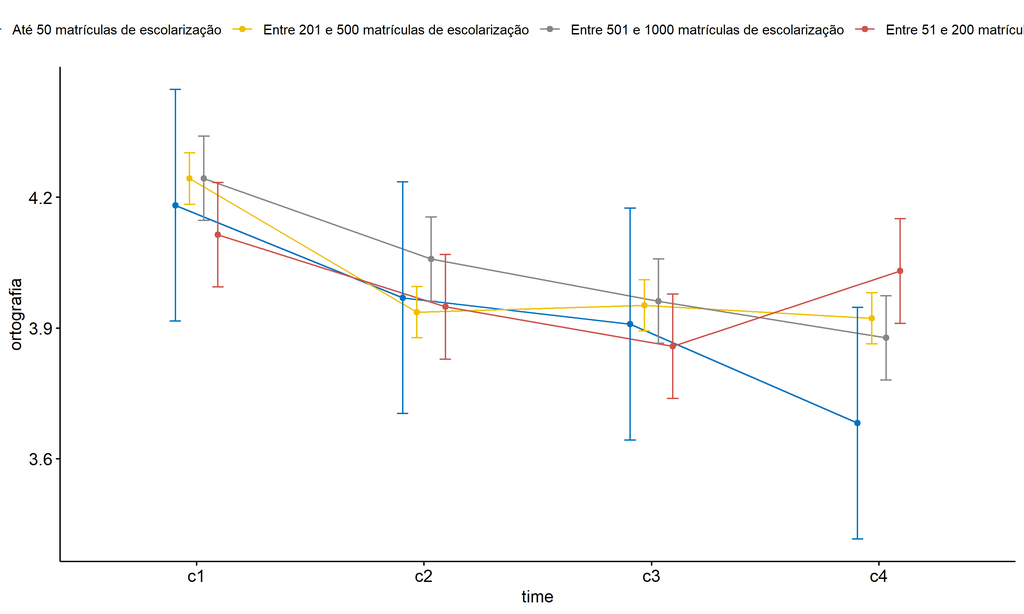

```r
pwc <- add_xy_position(pwc, x = "time", fun = "mean_se", dodge = 0.25)
pd <- position_dodge(width = 0.25)
ggline(emms, x = "time", y = "emmean", color = "porte",
       palette = c("#0073C2FF","#EFC000FF","#868686FF","#CD534CFF","#7AA6DCFF"),
       position = pd, ylab = "ortografia") +
  geom_errorbar(aes(ymin = conf.low, ymax = conf.high, color = porte),
                position = pd, width = 0.2) +
  stat_pvalue_manual(pwc, hide.ns = T, tip.length = F, linetype = 1)
```

```r
(pwc <- ldat %>% group_by(porte) %>%
    emmeans_test(ortografia ~ time, detailed = T, p.adjust.method = "bonferroni"))
```

```
## # A tibble: 24 × 15
##    porte     term  .y.   group1 group2 null.value estimate     se    df conf.low
##  * <fct>     <chr> <chr> <chr>  <chr>       <dbl>    <dbl>  <dbl> <dbl>    <dbl>
##  1 Até 50 m… time  orto… c1     c2              0   0.212  0.192   4460  -0.164
##  2 Até 50 m… time  orto… c1     c3              0   0.273  0.192   4460  -0.103
##  3 Até 50 m… time  orto… c1     c4              0   0.500  0.192   4460   0.124
##  4 Até 50 m… time  orto… c2     c3              0   0.0606 0.192   4460  -0.316
##  5 Até 50 m… time  orto… c2     c4              0   0.288  0.192   4460  -0.0882
##  6 Até 50 m… time  orto… c3     c4              0   0.227  0.192   4460  -0.149
##  7 Entre 20… time  orto… c1     c2              0   0.306  0.0424  4460   0.223
##  8 Entre 20… time  orto… c1     c3              0   0.291  0.0424  4460   0.208
##  9 Entre 20… time  orto… c1     c4              0   0.321  0.0424  4460   0.238
## 10 Entre 20… time  orto… c2     c3              0  -0.0153 0.0424  4460  -0.0985
## # ℹ 14 more rows
## # ℹ 5 more variables: conf.high <dbl>, statistic <dbl>, p <dbl>, p.adj <dbl>,
## #   p.adj.signif <chr>
```

| porte | term | .y. | group1 | group2 | null.value | estimate | se | df | conf.low | conf.high | statistic | p | p.adj | p.adj.signif |
| --- | --- | --- | --- | --- | --- | --- | --- | --- | --- | --- | --- | --- | --- | --- |
| Até 50 matrículas de escolarização | time | ortografia | c1 | c2 | 0 | 0.212 | 0.192 | 4460 | -0.164 | 0.588 | 1.106 | 0.269 | 1.000 | ns |
| Até 50 matrículas de escolarização | time | ortografia | c1 | c3 | 0 | 0.273 | 0.192 | 4460 | -0.103 | 0.649 | 1.422 | 0.155 | 0.931 | ns |
| Até 50 matrículas de escolarização | time | ortografia | c1 | c4 | 0 | 0.500 | 0.192 | 4460 | 0.124 | 0.876 | 2.606 | 0.009 | 0.055 | ns |
| Até 50 matrículas de escolarização | time | ortografia | c2 | c3 | 0 | 0.061 | 0.192 | 4460 | -0.316 | 0.437 | 0.316 | 0.752 | 1.000 | ns |
| Até 50 matrículas de escolarização | time | ortografia | c2 | c4 | 0 | 0.288 | 0.192 | 4460 | -0.088 | 0.664 | 1.501 | 0.134 | 0.801 | ns |
| Até 50 matrículas de escolarização | time | ortografia | c3 | c4 | 0 | 0.227 | 0.192 | 4460 | -0.149 | 0.603 | 1.185 | 0.236 | 1.000 | ns |
| Entre 201 e 500 matrículas de escolarização | time | ortografia | c1 | c2 | 0 | 0.306 | 0.042 | 4460 | 0.223 | 0.390 | 7.224 | 0.000 | 0.000 | **** |
| Entre 201 e 500 matrículas de escolarização | time | ortografia | c1 | c3 | 0 | 0.291 | 0.042 | 4460 | 0.208 | 0.374 | 6.863 | 0.000 | 0.000 | **** |
| Entre 201 e 500 matrículas de escolarização | time | ortografia | c1 | c4 | 0 | 0.321 | 0.042 | 4460 | 0.238 | 0.404 | 7.561 | 0.000 | 0.000 | **** |
| Entre 201 e 500 matrículas de escolarização | time | ortografia | c2 | c3 | 0 | -0.015 | 0.042 | 4460 | -0.098 | 0.068 | -0.361 | 0.718 | 1.000 | ns |
| Entre 201 e 500 matrículas de escolarização | time | ortografia | c2 | c4 | 0 | 0.014 | 0.042 | 4460 | -0.069 | 0.097 | 0.338 | 0.736 | 1.000 | ns |
| Entre 201 e 500 matrículas de escolarização | time | ortografia | c3 | c4 | 0 | 0.030 | 0.042 | 4460 | -0.054 | 0.113 | 0.699 | 0.485 | 1.000 | ns |
| Entre 501 e 1000 matrículas de escolarização | time | ortografia | c1 | c2 | 0 | 0.185 | 0.070 | 4460 | 0.048 | 0.322 | 2.655 | 0.008 | 0.048 | * |
| Entre 501 e 1000 matrículas de escolarização | time | ortografia | c1 | c3 | 0 | 0.282 | 0.070 | 4460 | 0.145 | 0.419 | 4.035 | 0.000 | 0.000 | *** |
| Entre 501 e 1000 matrículas de escolarização | time | ortografia | c1 | c4 | 0 | 0.366 | 0.070 | 4460 | 0.229 | 0.503 | 5.242 | 0.000 | 0.000 | **** |
| Entre 501 e 1000 matrículas de escolarização | time | ortografia | c2 | c3 | 0 | 0.096 | 0.070 | 4460 | -0.041 | 0.233 | 1.380 | 0.168 | 1.000 | ns |
| Entre 501 e 1000 matrículas de escolarização | time | ortografia | c2 | c4 | 0 | 0.181 | 0.070 | 4460 | 0.044 | 0.318 | 2.588 | 0.010 | 0.058 | ns |
| Entre 501 e 1000 matrículas de escolarização | time | ortografia | c3 | c4 | 0 | 0.084 | 0.070 | 4460 | -0.053 | 0.221 | 1.208 | 0.227 | 1.000 | ns |
| Entre 51 e 200 matrículas de escolarização | time | ortografia | c1 | c2 | 0 | 0.166 | 0.087 | 4460 | -0.004 | 0.335 | 1.913 | 0.056 | 0.335 | ns |
| Entre 51 e 200 matrículas de escolarização | time | ortografia | c1 | c3 | 0 | 0.256 | 0.087 | 4460 | 0.086 | 0.426 | 2.959 | 0.003 | 0.019 | * |
| Entre 51 e 200 matrículas de escolarização | time | ortografia | c1 | c4 | 0 | 0.083 | 0.087 | 4460 | -0.086 | 0.253 | 0.962 | 0.336 | 1.000 | ns |
| Entre 51 e 200 matrículas de escolarização | time | ortografia | c2 | c3 | 0 | 0.091 | 0.087 | 4460 | -0.079 | 0.260 | 1.046 | 0.296 | 1.000 | ns |
| Entre 51 e 200 matrículas de escolarização | time | ortografia | c2 | c4 | 0 | -0.082 | 0.087 | 4460 | -0.252 | 0.087 | -0.951 | 0.342 | 1.000 | ns |
| Entre 51 e 200 matrículas de escolarização | time | ortografia | c3 | c4 | 0 | -0.173 | 0.087 | 4460 | -0.343 | -0.003 | -1.996 | 0.046 | 0.276 | ns |

```r
(emms <- get_emmeans(pwc))
```

```
## # A tibble: 16 × 8
##    porte                     time  emmean     se    df conf.low conf.high method
##    <fct>                     <fct>  <dbl>  <dbl> <dbl>    <dbl>     <dbl> <chr>
##  1 Até 50 matrículas de esc… c1      4.18 0.136   4460     3.92      4.45 Emmea…
##  2 Até 50 matrículas de esc… c2      3.97 0.136   4460     3.70      4.24 Emmea…
##  3 Até 50 matrículas de esc… c3      3.91 0.136   4460     3.64      4.18 Emmea…
##  4 Até 50 matrículas de esc… c4      3.68 0.136   4460     3.42      3.95 Emmea…
##  5 Entre 201 e 500 matrícul… c1      4.24 0.0300  4460     4.18      4.30 Emmea…
##  6 Entre 201 e 500 matrícul… c2      3.94 0.0300  4460     3.88      4.00 Emmea…
##  7 Entre 201 e 500 matrícul… c3      3.95 0.0300  4460     3.89      4.01 Emmea…
##  8 Entre 201 e 500 matrícul… c4      3.92 0.0300  4460     3.86      3.98 Emmea…
##  9 Entre 501 e 1000 matrícu… c1      4.24 0.0494  4460     4.15      4.34 Emmea…
## 10 Entre 501 e 1000 matrícu… c2      4.06 0.0494  4460     3.96      4.16 Emmea…
## 11 Entre 501 e 1000 matrícu… c3      3.96 0.0494  4460     3.87      4.06 Emmea…
## 12 Entre 501 e 1000 matrícu… c4      3.88 0.0494  4460     3.78      3.97 Emmea…
## 13 Entre 51 e 200 matrícula… c1      4.11 0.0612  4460     3.99      4.23 Emmea…
## 14 Entre 51 e 200 matrícula… c2      3.95 0.0612  4460     3.83      4.07 Emmea…
## 15 Entre 51 e 200 matrícula… c3      3.86 0.0612  4460     3.74      3.98 Emmea…
## 16 Entre 51 e 200 matrícula… c4      4.03 0.0612  4460     3.91      4.15 Emmea…
```

| porte | time | emmean | se | df | conf.low | conf.high | method |
| --- | --- | --- | --- | --- | --- | --- | --- |
| Até 50 matrículas de escolarização | c1 | 4.182 | 0.136 | 4460 | 3.916 | 4.448 | Emmeans test |
| Até 50 matrículas de escolarização | c2 | 3.970 | 0.136 | 4460 | 3.704 | 4.236 | Emmeans test |
| Até 50 matrículas de escolarização | c3 | 3.909 | 0.136 | 4460 | 3.643 | 4.175 | Emmeans test |
| Até 50 matrículas de escolarização | c4 | 3.682 | 0.136 | 4460 | 3.416 | 3.948 | Emmeans test |
| Entre 201 e 500 matrículas de escolarização | c1 | 4.243 | 0.030 | 4460 | 4.184 | 4.302 | Emmeans test |
| Entre 201 e 500 matrículas de escolarização | c2 | 3.937 | 0.030 | 4460 | 3.878 | 3.995 | Emmeans test |
| Entre 201 e 500 matrículas de escolarização | c3 | 3.952 | 0.030 | 4460 | 3.893 | 4.011 | Emmeans test |
| Entre 201 e 500 matrículas de escolarização | c4 | 3.922 | 0.030 | 4460 | 3.863 | 3.981 | Emmeans test |
| Entre 501 e 1000 matrículas de escolarização | c1 | 4.244 | 0.049 | 4460 | 4.147 | 4.340 | Emmeans test |
| Entre 501 e 1000 matrículas de escolarização | c2 | 4.058 | 0.049 | 4460 | 3.961 | 4.155 | Emmeans test |
| Entre 501 e 1000 matrículas de escolarização | c3 | 3.962 | 0.049 | 4460 | 3.865 | 4.059 | Emmeans test |
| Entre 501 e 1000 matrículas de escolarização | c4 | 3.878 | 0.049 | 4460 | 3.781 | 3.974 | Emmeans test |
| Entre 51 e 200 matrículas de escolarização | c1 | 4.114 | 0.061 | 4460 | 3.994 | 4.234 | Emmeans test |
| Entre 51 e 200 matrículas de escolarização | c2 | 3.949 | 0.061 | 4460 | 3.829 | 4.069 | Emmeans test |
| Entre 51 e 200 matrículas de escolarização | c3 | 3.858 | 0.061 | 4460 | 3.738 | 3.978 | Emmeans test |
| Entre 51 e 200 matrículas de escolarização | c4 | 4.031 | 0.061 | 4460 | 3.911 | 4.151 | Emmeans test |

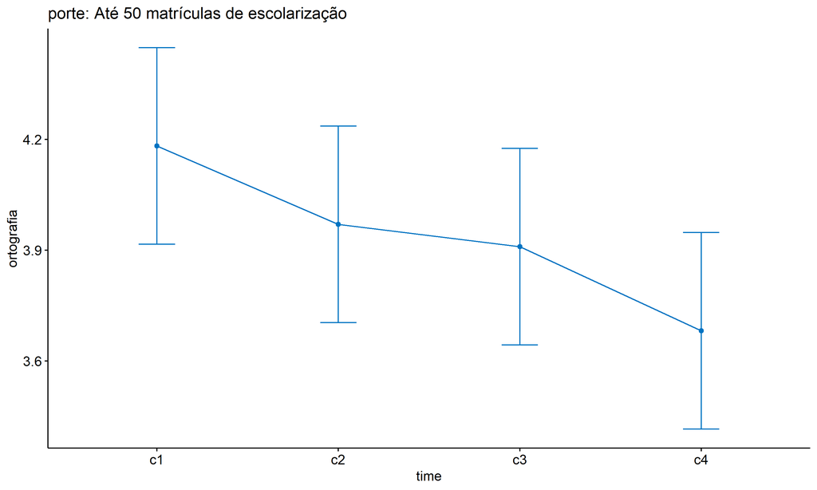

```r
emms.gg <- emms[which(emms$porte == "Até 50 matrículas de escolarização"),]
if (nrow(emms.gg) > 0)
  ggline(emms.gg, x = "time", y = "emmean", color = "#0073C2FF", ylab = "ortografia") +
    geom_errorbar(aes(ymin = conf.low, ymax = conf.high),
                  width = 0.2, color = "#0073C2FF") +
    stat_pvalue_manual(
      add_xy_position(pwc[which(pwc$porte == "Até 50 matrículas de escolarização"),],
                      x = "time", fun = "mean_se"),
      hide.ns = T, color = "#0073C2FF", tip.length = F) +
    labs(title = "porte: Até 50 matrículas de escolarização")+
    theme(legend.text = element_blank())
```

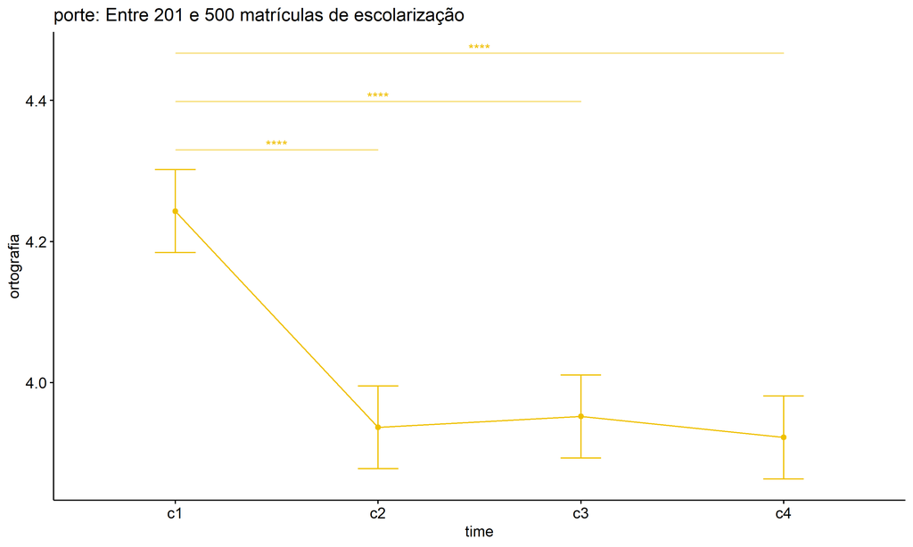

```r
emms.gg <- emms[which(emms$porte == "Entre 201 e 500 matrículas de escolarização"),]
if (nrow(emms.gg) > 0)
  ggline(emms.gg, x = "time", y = "emmean", color = "#EFC000FF", ylab = "ortografia") +
    geom_errorbar(aes(ymin = conf.low, ymax = conf.high),
                  width = 0.2, color = "#EFC000FF") +
    stat_pvalue_manual(
      add_xy_position(pwc[which(pwc$porte == "Entre 201 e 500 matrículas de escolarização"),],
                      x = "time", fun = "mean_se"),
      hide.ns = T, color = "#EFC000FF", tip.length = F) +
    labs(title = "porte: Entre 201 e 500 matrículas de escolarização")+
    theme(legend.text = element_blank())
```

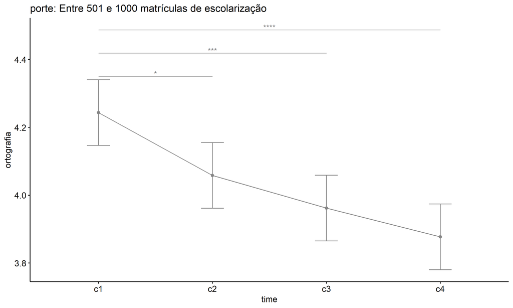

```r
emms.gg <- emms[which(emms$porte == "Entre 501 e 1000 matrículas de escolarização"),]
if (nrow(emms.gg) > 0)
  ggline(emms.gg, x = "time", y = "emmean", color = "#868686FF", ylab = "ortografia") +
    geom_errorbar(aes(ymin = conf.low, ymax = conf.high),
                  width = 0.2, color = "#868686FF") +
    stat_pvalue_manual(
      add_xy_position(pwc[which(pwc$porte == "Entre 501 e 1000 matrículas de escolarização"),],
                      x = "time", fun = "mean_se"),
      hide.ns = T, color = "#868686FF", tip.length = F) +
    labs(title = "porte: Entre 501 e 1000 matrículas de escolarização")+
    theme(legend.text = element_blank())
```

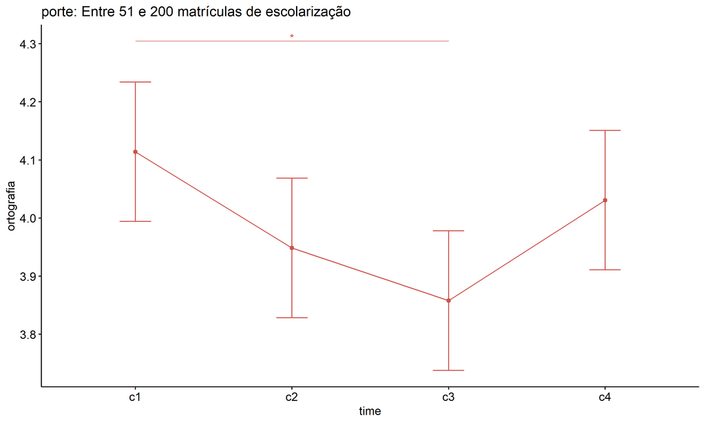

```r
emms.gg <- emms[which(emms$porte == "Entre 51 e 200 matrículas de escolarização"),]
if (nrow(emms.gg) > 0)
  ggline(emms.gg, x = "time", y = "emmean", color = "#CD534CFF", ylab = "ortografia") +
    geom_errorbar(aes(ymin = conf.low, ymax = conf.high),
                  width = 0.2, color = "#CD534CFF") +
    stat_pvalue_manual(
      add_xy_position(pwc[which(pwc$porte == "Entre 51 e 200 matrículas de escolarização"),],
                      x = "time", fun = "mean_se"),
      hide.ns = T, color = "#CD534CFF", tip.length = F) +
    labs(title = "porte: Entre 51 e 200 matrículas de escolarização")+
    theme(legend.text = element_blank())
```

```r
emms.gg <- emms[which(emms$porte == "Mais de 1000 matrículas de escolarização"),]
if (nrow(emms.gg) > 0)
  ggline(emms.gg, x = "time", y = "emmean", color = "#7AA6DCFF", ylab = "ortografia") +
    geom_errorbar(aes(ymin = conf.low, ymax = conf.high),
                  width = 0.2, color = "#7AA6DCFF") +
    stat_pvalue_manual(
      add_xy_position(pwc[which(pwc$porte == "Mais de 1000 matrículas de escolarização"),],
                      x = "time", fun = "mean_se"),
      hide.ns = T, color = "#7AA6DCFF", tip.length = F) +
    labs(title = "porte: Mais de 1000 matrículas de escolarização")+
    theme(legend.text = element_blank())
```